# Estimated Delivery Date: A case study

When shopping at Farfetch, customers are offered a catalog of thousands of products that are sourced from different partners spread around the world. During the shopping experience, customers must have an accurate estimate of their purchase delivery date to manage their expectations.

The goal of this case study is to **understand the Expected Delivery Date of an order and provide a robust and accurate delivery date estimate** to the customer. To support your understanding of the problem and development of the challenge you will receive a dataset split in training and test set. Further details are given in the Data Instructions attached to the case.

### Data Ingestion

We are going to start this study by ingesting the given dataset and verifying its data quality, in order to manage any problem that might appear.

```python
import matplotlib
import time
import numpy as np
import pandas as pd
import pandas_profiling as pp

from geopy import distance
from geopy import geocoders
from geopy.geocoders import Nominatim

from sklearn.preprocessing import LabelEncoder
from sklearn.preprocessing import OneHotEncoder
from sklearn.preprocessing import StandardScaler
from sklearn.pipeline import Pipeline
from sklearn.model_selection import train_test_split
from sklearn.model_selection import GridSearchCV

from sklearn.linear_model import LinearRegression
from sklearn.ensemble import RandomForestRegressor
from sklearn.tree import DecisionTreeRegressor
from sklearn.ensemble import AdaBoostRegressor
```

```python
%matplotlib inline
```

```python
dataFile = pd.read_csv('data/train.csv')
df= pd.DataFrame(dataFile)
```

```python
# First data inspection
df.head()
```

|  | OrderLineID | OrderCodeID | PartnerID | CustomerCountry | CustomerCity | CustomerLatitude | CustomerLongitude | PartnerLatitude | PartnerLongitude | PartnerCountry | PartnerCity | DeliveryType | IsHazmat | TariffCode | DdpCategory | DdpSubcategory | Category1stLevel | Category2ndLevel | OrderDate | DeliveryTime |
| --- | --- | --- | --- | --- | --- | --- | --- | --- | --- | --- | --- | --- | --- | --- | --- | --- | --- | --- | --- | --- |
| 0 | 3585 | BBR10944434 | 9949 | Singapore | singapore | 1.280094 | 103.850949 | 51.331300 | 0.445068 | United Kingdom | Snodland | Express | No | 6109.10.00 | Clothing & Accessories | T-shirts singlets and other vests | Clothing | T-Shirts & Vests | 2017-05-11 08:39:40 | 4.04 |
| 1 | 1339 | BIR4931334 | 9673 | China | Beijing | 39.904030 | 116.407526 | 45.962640 | 12.655136 | Italy | Pordenone | Express | No | 4202.12.80 | Bags & similar | Trunks suitcases vanity cases executive-cas... | Bags | Backpacks | 2016-02-04 13:19:13 | 9.88 |
| 2 | 4448 | GRM6588384 | 9383 | United Kingdom | Altrincham | 53.390180 | -2.350904 | 41.872389 | 12.480180 | Italy | Rome | Standard | No | 6203.43.20 | Clothing & Accessories | Trousers overalls shorts | Clothing | All in One | 2016-07-12 12:08:41 | 6.88 |
| 3 | 1817 | MBT12633964 | 9579 | Bulgaria | Varna | 43.204665 | 27.910542 | 45.676552 | 9.236743 | Italy | CARATE BRIANZA | Express | No | 0000.00.00 | default value | NaN | Bags | Tote Bags | 2017-07-26 13:30:31 | 5.83 |
| 4 | 18475 | PRT9869856 | 9671 | Denmark | Aalborg | 57.048819 | 9.921747 | 44.057082 | 12.564600 | Italy | Rimini | Standard | No | 6109.10.00 | Clothing & Accessories | T-shirts singlets and other vests | Clothing | T-Shirts & Vests | 2017-03-09 09:53:18 | 6.25 |

```python
# Checking out dataset shape
df.shape
```

```
(13441, 20)
```

```python
# Data types and info
df.info()
```

```
<class 'pandas.core.frame.DataFrame'>
RangeIndex: 13441 entries, 0 to 13440
Data columns (total 20 columns):
OrderLineID          13441 non-null int64
OrderCodeID          13441 non-null object
PartnerID            13441 non-null int64
CustomerCountry      13441 non-null object
CustomerCity         13436 non-null object
CustomerLatitude     12005 non-null float64
CustomerLongitude    12005 non-null float64
PartnerLatitude      12808 non-null float64
PartnerLongitude     12808 non-null float64
PartnerCountry       13435 non-null object
PartnerCity          13435 non-null object
DeliveryType         13441 non-null object
IsHazmat             13441 non-null object
TariffCode           12661 non-null object
DdpCategory          12661 non-null object
DdpSubcategory       11509 non-null object
Category1stLevel     13440 non-null object
Category2ndLevel     13439 non-null object
OrderDate            13441 non-null object
DeliveryTime         13441 non-null float64
dtypes: float64(5), int64(2), object(13)
memory usage: 2.1+ MB
```

```python
# Verifying duplicated data
dfDuplicated = pd.DataFrame.duplicated(df,keep='first')
dfDuplicated.sum()
```

```
0
```

### Exploratory Data Analysis

Let us investigate the dataset more deeply.

```python
# Detailed report
pr = pp.ProfileReport(df)
```

Overview

Dataset info

| Number of variables | 20 |
| --- | --- |
| Number of observations | 13441 |
| Total Missing (%) | 2.8% |
| Total size in memory | 2.1 MiB |
| Average record size in memory | 160.0 B |

Variables types

| Numeric | 7 |
| --- | --- |
| Categorical | 12 |
| Boolean | 0 |
| Date | 0 |
| Text (Unique) | 0 |
| Rejected | 1 |
| Unsupported | 0 |

Warnings

- `Category2ndLevel` has a high cardinality: 129 distinct values Warning

- `CustomerCity` has a high cardinality: 5333 distinct values Warning

- `CustomerCountry` has a high cardinality: 99 distinct values Warning

- `CustomerLatitude` has 1436 / 10.7% missing values Missing

- `CustomerLongitude` has 1436 / 10.7% missing values Missing

- `DdpCategory` has 780 / 5.8% missing values Missing

- `DdpSubcategory` has 1932 / 14.4% missing values Missing

- `DdpSubcategory` has a high cardinality: 83 distinct values Warning

- `IsHazmat` has constant value No Rejected

- `OrderCodeID` has a high cardinality: 13436 distinct values Warning

- `OrderDate` has a high cardinality: 13406 distinct values Warning

- `PartnerCity` has a high cardinality: 402 distinct values Warning

- `PartnerLatitude` has 633 / 4.7% missing values Missing

- `PartnerLongitude` has 633 / 4.7% missing values Missing

- `TariffCode` has 780 / 5.8% missing values Missing

- `TariffCode` has a high cardinality: 348 distinct values Warning

Variables

Category1stLevel  
Categorical

| Distinct count | 27 |
| --- | --- |
| Unique (%) | 0.2% |
| Missing (%) | 0.0% |
| Missing (n) | 1 |

| Clothing | 7100 |
| --- | --- |
| Shoes | 3446 |
| Bags | 980 |
| Other values (23) | 1914 |

Toggle details

| Value | Count | Frequency (%) |  |
| --- | --- | --- | --- |
| Clothing | 7100 | 52.8% |  |
| Shoes | 3446 | 25.6% |  |
| Bags | 980 | 7.3% |  |
| Accessories | 865 | 6.4% |  |
| Girls Clothing | 212 | 1.6% |  |
| Boys Clothing | 212 | 1.6% |  |
| Lifestyle | 161 | 1.2% |  |
| Jewellery | 132 | 1.0% |  |
| Baby Boy Clothing | 77 | 0.6% |  |
| Baby Girl Clothing | 61 | 0.5% |  |
| Other values (16) | 194 | 1.4% |  |

Category2ndLevel  
Categorical

| Distinct count | 129 |
| --- | --- |
| Unique (%) | 1.0% |
| Missing (%) | 0.0% |
| Missing (n) | 2 |

| Tops | 1466 |
| --- | --- |
| Trainers | 1173 |
| T-Shirts & Vests | 1147 |
| Other values (125) | 9653 |

Toggle details

| Value | Count | Frequency (%) |  |
| --- | --- | --- | --- |
| Tops | 1466 | 10.9% |  |
| Trainers | 1173 | 8.7% |  |
| T-Shirts & Vests | 1147 | 8.5% |  |
| Sweaters & Knitwear | 727 | 5.4% |  |
| Trousers | 695 | 5.2% |  |
| Jackets | 617 | 4.6% |  |
| Dresses | 613 | 4.6% |  |
| Boots | 436 | 3.2% |  |
| Knitwear | 434 | 3.2% |  |
| Denim | 429 | 3.2% |  |
| Other values (118) | 5702 | 42.4% |  |

CustomerCity  
Categorical

| Distinct count | 5333 |
| --- | --- |
| Unique (%) | 39.7% |
| Missing (%) | 0.0% |
| Missing (n) | 5 |

| Moscow | 443 |
| --- | --- |
| Hong Kong | 335 |
| London | 321 |
| Other values (5329) | 12337 |

Toggle details

| Value | Count | Frequency (%) |  |
| --- | --- | --- | --- |
| Moscow | 443 | 3.3% |  |
| Hong Kong | 335 | 2.5% |  |
| London | 321 | 2.4% |  |
| New York | 219 | 1.6% |  |
| Sydney | 183 | 1.4% |  |
| Singapore | 158 | 1.2% |  |
| Melbourne | 140 | 1.0% |  |
| Shanghai | 124 | 0.9% |  |
| Beijing | 107 | 0.8% |  |
| Brooklyn | 95 | 0.7% |  |
| Other values (5322) | 11311 | 84.2% |  |

CustomerCountry  
Categorical

| Distinct count | 99 |
| --- | --- |
| Unique (%) | 0.7% |
| Missing (%) | 0.0% |
| Missing (n) | 0 |

| United States | 3226 |
| --- | --- |
| Russian Federation | 1256 |
| United Kingdom | 931 |
| Other values (96) | 8028 |

Toggle details

| Value | Count | Frequency (%) |  |
| --- | --- | --- | --- |
| United States | 3226 | 24.0% |  |
| Russian Federation | 1256 | 9.3% |  |
| United Kingdom | 931 | 6.9% |  |
| Australia | 915 | 6.8% |  |
| Hong Kong | 880 | 6.5% |  |
| Germany | 654 | 4.9% |  |
| Japan | 594 | 4.4% |  |
| China | 580 | 4.3% |  |
| Korea Republic of | 380 | 2.8% |  |
| France | 308 | 2.3% |  |
| Other values (89) | 3717 | 27.7% |  |

CustomerLatitude  
Numeric

| Distinct count | 3110 |
| --- | --- |
| Unique (%) | 23.1% |
| Missing (%) | 10.7% |
| Missing (n) | 1436 |
| Infinite (%) | 0.0% |
| Infinite (n) | 0 |

| Mean | 33.033 |
| --- | --- |
| Minimum | -46.099 |
| Maximum | 68.957 |
| Zeros (%) | 0.0% |

Toggle details

**Statistics**

Quantile statistics

| Minimum | -46.099 |
| --- | --- |
| 5-th percentile | -33.867 |
| Q1 | 25.69 |
| Median | 39.952 |
| Q3 | 48.893 |
| 95-th percentile | 55.756 |
| Maximum | 68.957 |
| Range | 115.06 |
| Interquartile range | 23.203 |

Descriptive statistics

| Standard deviation | 23.82 |
| --- | --- |
| Coef of variation | 0.72111 |
| Kurtosis | 2.6819 |
| Mean | 33.033 |
| MAD | 16.597 |
| Skewness | -1.7922 |
| Sum | 396560 |
| Variance | 567.41 |
| Memory size | 105.1 KiB |

**Histogram**

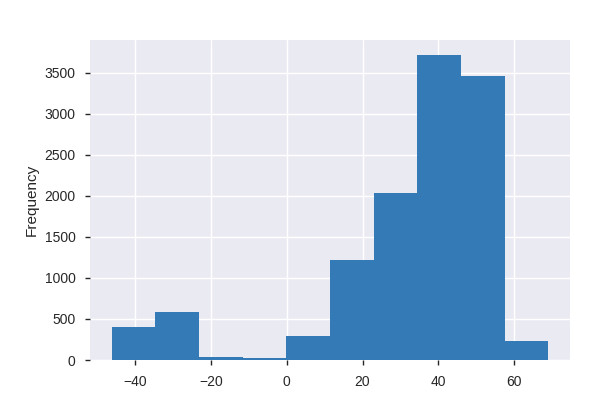

**Common Values**

| Value | Count | Frequency (%) |  |
| --- | --- | --- | --- |
| 22.396428 | 611 | 4.5% |  |
| 55.755826 | 527 | 3.9% |  |
| 51.508515 | 383 | 2.8% |  |
| 40.7056308 | 332 | 2.5% |  |
| -33.8674869 | 215 | 1.6% |  |
| 1.2800945 | 210 | 1.6% |  |
| -37.814107 | 177 | 1.3% |  |
| 22.1960033 | 154 | 1.1% |  |
| 34.0522342 | 135 | 1.0% |  |
| 31.230416 | 128 | 1.0% |  |
| Other values (3099) | 9133 | 67.9% |  |
| (Missing) | 1436 | 10.7% |  |

**Extreme Values**

Minimum 5 values

| Value | Count | Frequency (%) |  |
| --- | --- | --- | --- |
| -46.0987992 | 1 | 0.0% |  |
| -43.5320544 | 2 | 0.0% |  |
| -42.8819032 | 4 | 0.0% |  |
| -42.3002453 | 1 | 0.0% |  |
| -41.5134425 | 1 | 0.0% |  |

Maximum 5 values

| Value | Count | Frequency (%) |  |
| --- | --- | --- | --- |
| 64.5333333 | 1 | 0.0% |  |
| 64.566667 | 1 | 0.0% |  |
| 65.534473 | 1 | 0.0% |  |
| 66.5333333 | 1 | 0.0% |  |
| 68.9568301 | 2 | 0.0% |  |

CustomerLongitude  
Numeric

| Distinct count | 3110 |
| --- | --- |
| Unique (%) | 23.1% |
| Missing (%) | 10.7% |
| Missing (n) | 1436 |
| Infinite (%) | 0.0% |
| Infinite (n) | 0 |

| Mean | 18.759 |
| --- | --- |
| Minimum | -158.1 |
| Maximum | 176.25 |
| Zeros (%) | 0.0% |

Toggle details

**Statistics**

Quantile statistics

| Minimum | -158.1 |
| --- | --- |
| 5-th percentile | -118.24 |
| Q1 | -73.978 |
| Median | 13.405 |
| Q3 | 113.55 |
| 95-th percentile | 145.04 |
| Maximum | 176.25 |
| Range | 334.35 |
| Interquartile range | 187.52 |

Descriptive statistics

| Standard deviation | 85.539 |
| --- | --- |
| Coef of variation | 4.5598 |
| Kurtosis | -1.1709 |
| Mean | 18.759 |
| MAD | 71.078 |
| Skewness | -0.075306 |
| Sum | 225210 |
| Variance | 7316.9 |
| Memory size | 105.1 KiB |

**Histogram**

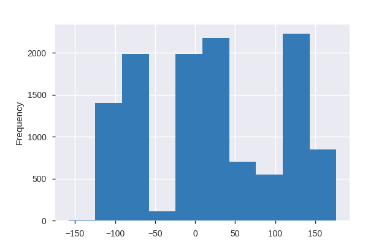

**Common Values**

| Value | Count | Frequency (%) |  |
| --- | --- | --- | --- |
| 114.109497 | 611 | 4.5% |  |
| 37.6173 | 527 | 3.9% |  |
| -0.1254872 | 383 | 2.8% |  |
| -73.9780035 | 332 | 2.5% |  |
| 151.2069902 | 215 | 1.6% |  |
| 103.8509491 | 210 | 1.6% |  |
| 144.96328 | 177 | 1.3% |  |
| 113.5460653 | 154 | 1.1% |  |
| -118.2436849 | 135 | 1.0% |  |
| 121.473701 | 128 | 1.0% |  |
| Other values (3099) | 9133 | 67.9% |  |
| (Missing) | 1436 | 10.7% |  |

**Extreme Values**

Minimum 5 values

| Value | Count | Frequency (%) |  |
| --- | --- | --- | --- |
| -158.1034112 | 1 | 0.0% |  |
| -158.0568965 | 1 | 0.0% |  |
| -157.8583333 | 3 | 0.0% |  |
| -149.9002778 | 1 | 0.0% |  |
| -123.8312534 | 3 | 0.0% |  |

Maximum 5 values

| Value | Count | Frequency (%) |  |
| --- | --- | --- | --- |
| 173.9612498 | 1 | 0.0% |  |
| 174.7633315 | 26 | 0.2% |  |
| 174.776236 | 1 | 0.0% |  |
| 174.9509887 | 1 | 0.0% |  |
| 176.2497461 | 1 | 0.0% |  |

DdpCategory  
Categorical

| Distinct count | 35 |
| --- | --- |
| Unique (%) | 0.3% |
| Missing (%) | 5.8% |
| Missing (n) | 780 |

| Clothing & Accessories | 6267 |
| --- | --- |
| Footwear with outer soles of rubber plastics leather or composition leather and uppers of textile materials | 1580 |
| Footwear with outer soles of rubber plastics leather or composition leather and uppers of leather | 1377 |
| Other values (31) | 3437 |

Toggle details

| Value | Count | Frequency (%) |  |
| --- | --- | --- | --- |
| Clothing & Accessories | 6267 | 46.6% |  |
| Footwear with outer soles of rubber plastics leather or composition leather and uppers of textile materials | 1580 | 11.8% |  |
| Footwear with outer soles of rubber plastics leather or composition leather and uppers of leather | 1377 | 10.2% |  |
| Bags & similar | 1206 | 9.0% |  |
| default value | 1152 | 8.6% |  |
| Kids' Clothing & Accessories | 378 | 2.8% |  |
| Hats and Headwear | 200 | 1.5% |  |
| Babies' garments and clothing accessories | 131 | 1.0% |  |
| Imitation jewellery | 82 | 0.6% |  |
| Optical lenses | 77 | 0.6% |  |
| Other values (24) | 211 | 1.6% |  |
| (Missing) | 780 | 5.8% |  |

DdpSubcategory  
Categorical

| Distinct count | 83 |
| --- | --- |
| Unique (%) | 0.6% |
| Missing (%) | 14.4% |
| Missing (n) | 1932 |

| Footwear with outer soles of rubber or plastics | 1475 |
| --- | --- |
| T-shirts singlets and other vests | 1460 |
| Jerseys pullovers cardigans waistcoats and similar articles knitted or crocheted | 1320 |
| Other values (79) | 7254 |
| (Missing) | 1932 |

Toggle details

| Value | Count | Frequency (%) |  |
| --- | --- | --- | --- |
| Footwear with outer soles of rubber or plastics | 1475 | 11.0% |  |
| T-shirts singlets and other vests | 1460 | 10.9% |  |
| Jerseys pullovers cardigans waistcoats and similar articles knitted or crocheted | 1320 | 9.8% |  |
| Trousers overalls shorts | 1139 | 8.5% |  |
| Other footwear with outer soles of leather | 800 | 6.0% |  |
| Handbags whether or not with shoulder strap including those without handle | 701 | 5.2% |  |
| Other footwear | 577 | 4.3% |  |
| Dresses | 509 | 3.8% |  |
| Blouses shirts and shirt-blouses | 422 | 3.1% |  |
| Jackets and blazers | 363 | 2.7% |  |
| Other values (72) | 2743 | 20.4% |  |
| (Missing) | 1932 | 14.4% |  |

DeliveryTime  
Numeric

| Distinct count | 493 |
| --- | --- |
| Unique (%) | 3.7% |
| Missing (%) | 0.0% |
| Missing (n) | 0 |
| Infinite (%) | 0.0% |
| Infinite (n) | 0 |

| Mean | 5.1202 |
| --- | --- |
| Minimum | 0.21 |
| Maximum | 191.5 |
| Zeros (%) | 0.0% |

Toggle details

**Statistics**

Quantile statistics

| Minimum | 0.21 |
| --- | --- |
| 5-th percentile | 1.83 |
| Q1 | 3.25 |
| Median | 4.54 |
| Q3 | 5.96 |
| 95-th percentile | 10 |
| Maximum | 191.5 |
| Range | 191.29 |
| Interquartile range | 2.71 |

Descriptive statistics

| Standard deviation | 4.1487 |
| --- | --- |
| Coef of variation | 0.81027 |
| Kurtosis | 600.55 |
| Mean | 5.1202 |
| MAD | 2.0502 |
| Skewness | 16.912 |
| Sum | 68820 |
| Variance | 17.212 |
| Memory size | 105.1 KiB |

**Histogram**

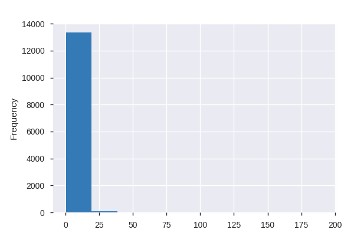

**Common Values**

| Value | Count | Frequency (%) |  |
| --- | --- | --- | --- |
| 3.79 | 156 | 1.2% |  |
| 3.88 | 146 | 1.1% |  |
| 3.96 | 144 | 1.1% |  |
| 4.0 | 143 | 1.1% |  |
| 4.88 | 143 | 1.1% |  |
| 3.92 | 140 | 1.0% |  |
| 4.83 | 137 | 1.0% |  |
| 4.79 | 134 | 1.0% |  |
| 3.83 | 132 | 1.0% |  |
| 4.75 | 132 | 1.0% |  |
| Other values (483) | 12034 | 89.5% |  |

**Extreme Values**

Minimum 5 values

| Value | Count | Frequency (%) |  |
| --- | --- | --- | --- |
| 0.21 | 1 | 0.0% |  |
| 0.33 | 1 | 0.0% |  |
| 0.58 | 1 | 0.0% |  |
| 0.67 | 1 | 0.0% |  |
| 0.79 | 4 | 0.0% |  |

Maximum 5 values

| Value | Count | Frequency (%) |  |
| --- | --- | --- | --- |
| 61.29 | 1 | 0.0% |  |
| 88.96 | 1 | 0.0% |  |
| 146.04 | 1 | 0.0% |  |
| 166.58 | 1 | 0.0% |  |
| 191.5 | 1 | 0.0% |  |

DeliveryType  
Categorical

| Distinct count | 2 |
| --- | --- |
| Unique (%) | 0.0% |
| Missing (%) | 0.0% |
| Missing (n) | 0 |

| Express | 11200 |
| --- | --- |
| Standard | 2241 |

Toggle details

| Value | Count | Frequency (%) |  |
| --- | --- | --- | --- |
| Express | 11200 | 83.3% |  |
| Standard | 2241 | 16.7% |  |

IsHazmat  
Constant

*This variable is constant and should be ignored for analysis*

| Constant value | No |
| --- | --- |

OrderCodeID  
Categorical

| Distinct count | 13436 |
| --- | --- |
| Unique (%) | 100.0% |
| Missing (%) | 0.0% |
| Missing (n) | 0 |

| PAS14138306 | 2 |
| --- | --- |
| ETR11211952 | 2 |
| VTK14584161 | 2 |
| Other values (13433) | 13435 |

Toggle details

| Value | Count | Frequency (%) |  |
| --- | --- | --- | --- |
| PAS14138306 | 2 | 0.0% |  |
| ETR11211952 | 2 | 0.0% |  |
| VTK14584161 | 2 | 0.0% |  |
| VTK13059165 | 2 | 0.0% |  |
| RCA6264635 | 2 | 0.0% |  |
| EXC8998340 | 1 | 0.0% |  |
| BRO8605378 | 1 | 0.0% |  |
| BIO6984369 | 1 | 0.0% |  |
| WHS13455100 | 1 | 0.0% |  |
| VTK9376501 | 1 | 0.0% |  |
| Other values (13426) | 13426 | 99.9% |  |

OrderDate  
Categorical

| Distinct count | 13406 |
| --- | --- |
| Unique (%) | 99.7% |
| Missing (%) | 0.0% |
| Missing (n) | 0 |

| 2017-11-16 13:21:07 | 2 |
| --- | --- |
| 2017-11-19 15:02:58 | 2 |
| 2016-07-12 06:08:25 | 2 |
| Other values (13403) | 13435 |

Toggle details

| Value | Count | Frequency (%) |  |
| --- | --- | --- | --- |
| 2017-11-16 13:21:07 | 2 | 0.0% |  |
| 2017-11-19 15:02:58 | 2 | 0.0% |  |
| 2016-07-12 06:08:25 | 2 | 0.0% |  |
| 2017-06-30 02:57:53 | 2 | 0.0% |  |
| 2016-04-09 17:34:29 | 2 | 0.0% |  |
| 2018-01-03 19:46:27 | 2 | 0.0% |  |
| 2017-08-27 17:49:46 | 2 | 0.0% |  |
| 2017-11-24 19:33:42 | 2 | 0.0% |  |
| 2016-10-07 08:23:40 | 2 | 0.0% |  |
| 2017-11-26 21:05:56 | 2 | 0.0% |  |
| Other values (13396) | 13421 | 99.9% |  |

OrderLineID  
Numeric

| Distinct count | 13441 |
| --- | --- |
| Unique (%) | 100.0% |
| Missing (%) | 0.0% |
| Missing (n) | 0 |
| Infinite (%) | 0.0% |
| Infinite (n) | 0 |

| Mean | 9984.2 |
| --- | --- |
| Minimum | 1 |
| Maximum | 19999 |
| Zeros (%) | 0.0% |

Toggle details

**Statistics**

Quantile statistics

| Minimum | 1 |
| --- | --- |
| 5-th percentile | 1015 |
| Q1 | 4972 |
| Median | 10014 |
| Q3 | 14950 |
| 95-th percentile | 19010 |
| Maximum | 19999 |
| Range | 19998 |
| Interquartile range | 9978 |

Descriptive statistics

| Standard deviation | 5775.3 |
| --- | --- |
| Coef of variation | 0.57844 |
| Kurtosis | -1.2 |
| Mean | 9984.2 |
| MAD | 5000.8 |
| Skewness | -0.00076752 |
| Sum | 134197416 |
| Variance | 33354000 |
| Memory size | 105.1 KiB |

**Histogram**

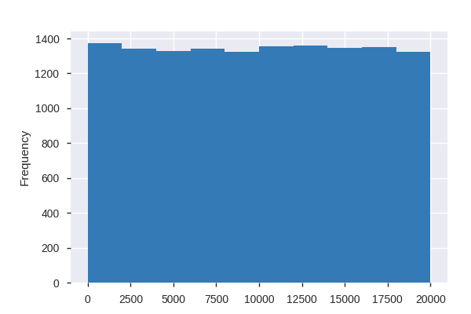

**Common Values**

| Value | Count | Frequency (%) |  |
| --- | --- | --- | --- |
| 4094 | 1 | 0.0% |  |
| 6726 | 1 | 0.0% |  |
| 4727 | 1 | 0.0% |  |
| 6774 | 1 | 0.0% |  |
| 629 | 1 | 0.0% |  |
| 2676 | 1 | 0.0% |  |
| 12915 | 1 | 0.0% |  |
| 14962 | 1 | 0.0% |  |
| 8817 | 1 | 0.0% |  |
| 10864 | 1 | 0.0% |  |
| Other values (13431) | 13431 | 99.9% |  |

**Extreme Values**

Minimum 5 values

| Value | Count | Frequency (%) |  |
| --- | --- | --- | --- |
| 1 | 1 | 0.0% |  |
| 2 | 1 | 0.0% |  |
| 3 | 1 | 0.0% |  |
| 9 | 1 | 0.0% |  |
| 10 | 1 | 0.0% |  |

Maximum 5 values

| Value | Count | Frequency (%) |  |
| --- | --- | --- | --- |
| 19988 | 1 | 0.0% |  |
| 19990 | 1 | 0.0% |  |
| 19997 | 1 | 0.0% |  |
| 19998 | 1 | 0.0% |  |
| 19999 | 1 | 0.0% |  |

PartnerCity  
Categorical

| Distinct count | 402 |
| --- | --- |
| Unique (%) | 3.0% |
| Missing (%) | 0.0% |
| Missing (n) | 6 |

| warsaw | 730 |
| --- | --- |
| TRAPANI | 607 |
| London | 512 |
| Other values (398) | 11586 |

Toggle details

| Value | Count | Frequency (%) |  |
| --- | --- | --- | --- |
| warsaw | 730 | 5.4% |  |
| TRAPANI | 607 | 4.5% |  |
| London | 512 | 3.8% |  |
| CEGGIA VE | 415 | 3.1% |  |
| Paris | 371 | 2.8% |  |
| Brimsdown | 360 | 2.7% |  |
| Parma | 336 | 2.5% |  |
| savio | 279 | 2.1% |  |
| Como | 225 | 1.7% |  |
| Milano | 213 | 1.6% |  |
| Other values (391) | 9387 | 69.8% |  |

PartnerCountry  
Categorical

| Distinct count | 45 |
| --- | --- |
| Unique (%) | 0.3% |
| Missing (%) | 0.0% |
| Missing (n) | 6 |

| Italy | 7308 |
| --- | --- |
| United Kingdom | 1351 |
| Poland | 792 |
| Other values (41) | 3984 |

Toggle details

| Value | Count | Frequency (%) |  |
| --- | --- | --- | --- |
| Italy | 7308 | 54.4% |  |
| United Kingdom | 1351 | 10.1% |  |
| Poland | 792 | 5.9% |  |
| United States | 716 | 5.3% |  |
| France | 710 | 5.3% |  |
| Spain | 690 | 5.1% |  |
| Germany | 397 | 3.0% |  |
| Portugal | 204 | 1.5% |  |
| Belgium | 115 | 0.9% |  |
| Austria | 114 | 0.8% |  |
| Other values (34) | 1038 | 7.7% |  |

PartnerID  
Numeric

| Distinct count | 814 |
| --- | --- |
| Unique (%) | 6.1% |
| Missing (%) | 0.0% |
| Missing (n) | 0 |
| Infinite (%) | 0.0% |
| Infinite (n) | 0 |

| Mean | 9685 |
| --- | --- |
| Minimum | 9003 |
| Maximum | 11189 |
| Zeros (%) | 0.0% |

Toggle details

**Statistics**

Quantile statistics

| Minimum | 9003 |
| --- | --- |
| 5-th percentile | 9058 |
| Q1 | 9339 |
| Median | 9579 |
| Q3 | 9945 |
| 95-th percentile | 10614 |
| Maximum | 11189 |
| Range | 2186 |
| Interquartile range | 606 |

Descriptive statistics

| Standard deviation | 451.88 |
| --- | --- |
| Coef of variation | 0.046657 |
| Kurtosis | 0.21644 |
| Mean | 9685 |
| MAD | 360.9 |
| Skewness | 0.85606 |
| Sum | 130176530 |
| Variance | 204190 |
| Memory size | 105.1 KiB |

**Histogram**

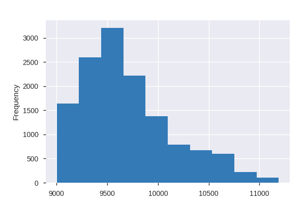

**Common Values**

| Value | Count | Frequency (%) |  |
| --- | --- | --- | --- |
| 9336 | 607 | 4.5% |  |
| 9462 | 516 | 3.8% |  |
| 9446 | 415 | 3.1% |  |
| 9475 | 333 | 2.5% |  |
| 10361 | 292 | 2.2% |  |
| 9306 | 279 | 2.1% |  |
| 9359 | 257 | 1.9% |  |
| 10614 | 202 | 1.5% |  |
| 9728 | 186 | 1.4% |  |
| 9681 | 183 | 1.4% |  |
| Other values (804) | 10171 | 75.7% |  |

**Extreme Values**

Minimum 5 values

| Value | Count | Frequency (%) |  |
| --- | --- | --- | --- |
| 9003 | 21 | 0.2% |  |
| 9006 | 32 | 0.2% |  |
| 9007 | 22 | 0.2% |  |
| 9008 | 11 | 0.1% |  |
| 9011 | 13 | 0.1% |  |

Maximum 5 values

| Value | Count | Frequency (%) |  |
| --- | --- | --- | --- |
| 11149 | 2 | 0.0% |  |
| 11162 | 2 | 0.0% |  |
| 11181 | 1 | 0.0% |  |
| 11183 | 2 | 0.0% |  |
| 11189 | 2 | 0.0% |  |

PartnerLatitude  
Numeric

| Distinct count | 354 |
| --- | --- |
| Unique (%) | 2.6% |
| Missing (%) | 4.7% |
| Missing (n) | 633 |
| Infinite (%) | 0.0% |
| Infinite (n) | 0 |

| Mean | 43.931 |
| --- | --- |
| Minimum | -38.195 |
| Maximum | 60.173 |
| Zeros (%) | 0.0% |

Toggle details

**Statistics**

Quantile statistics

| Minimum | -38.195 |
| --- | --- |
| 5-th percentile | 35.689 |
| Q1 | 40.984 |
| Median | 44.801 |
| Q3 | 48.857 |
| 95-th percentile | 52.23 |
| Maximum | 60.173 |
| Range | 98.368 |
| Interquartile range | 7.8722 |

Descriptive statistics

| Standard deviation | 8.9796 |
| --- | --- |
| Coef of variation | 0.2044 |
| Kurtosis | 40.847 |
| Mean | 43.931 |
| MAD | 4.892 |
| Skewness | -5.2167 |
| Sum | 562660 |
| Variance | 80.633 |
| Memory size | 105.1 KiB |

**Histogram**

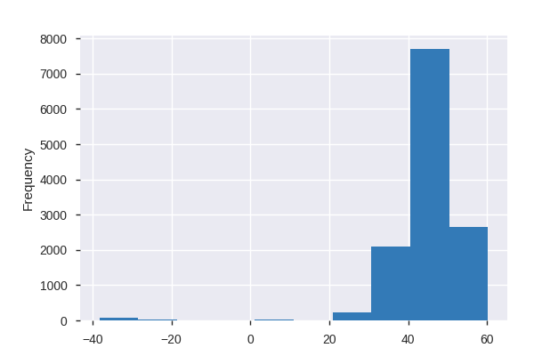

**Common Values**

| Value | Count | Frequency (%) |  |
| --- | --- | --- | --- |
| 52.2296756 | 730 | 5.4% |  |
| 38.0176177 | 607 | 4.5% |  |
| 51.508515 | 512 | 3.8% |  |
| 45.6890925 | 415 | 3.1% |  |
| 48.856614 | 371 | 2.8% |  |
| 51.652766 | 360 | 2.7% |  |
| 45.4654219 | 354 | 2.6% |  |
| 44.801485 | 336 | 2.5% |  |
| 41.8723889 | 280 | 2.1% |  |
| 44.323287 | 279 | 2.1% |  |
| Other values (343) | 8564 | 63.7% |  |
| (Missing) | 633 | 4.7% |  |

**Extreme Values**

Minimum 5 values

| Value | Count | Frequency (%) |  |
| --- | --- | --- | --- |
| -38.1951657 | 1 | 0.0% |  |
| -37.841228 | 3 | 0.0% |  |
| -37.8400982 | 2 | 0.0% |  |
| -37.814107 | 2 | 0.0% |  |
| -37.4713077 | 7 | 0.1% |  |

Maximum 5 values

| Value | Count | Frequency (%) |  |
| --- | --- | --- | --- |
| 55.6760968 | 38 | 0.3% |  |
| 56.9496487 | 23 | 0.2% |  |
| 57.0488195 | 1 | 0.0% |  |
| 59.3293235 | 7 | 0.1% |  |
| 60.1733244 | 9 | 0.1% |  |

PartnerLongitude  
Numeric

| Distinct count | 354 |
| --- | --- |
| Unique (%) | 2.6% |
| Missing (%) | 4.7% |
| Missing (n) | 633 |
| Infinite (%) | 0.0% |
| Infinite (n) | 0 |

| Mean | 6.421 |
| --- | --- |
| Minimum | -123.11 |
| Maximum | 174.76 |
| Zeros (%) | 0.0% |

Toggle details

**Statistics**

Quantile statistics

| Minimum | -123.11 |
| --- | --- |
| 5-th percentile | -73.978 |
| Q1 | 2.3522 |
| Median | 10.328 |
| Q3 | 13.361 |
| 95-th percentile | 21.012 |
| Maximum | 174.76 |
| Range | 297.88 |
| Interquartile range | 11.009 |

Descriptive statistics

| Standard deviation | 31.321 |
| --- | --- |
| Coef of variation | 4.8778 |
| Kurtosis | 9.7955 |
| Mean | 6.421 |
| MAD | 14.749 |
| Skewness | -0.47449 |
| Sum | 82240 |
| Variance | 980.98 |
| Memory size | 105.1 KiB |

**Histogram**

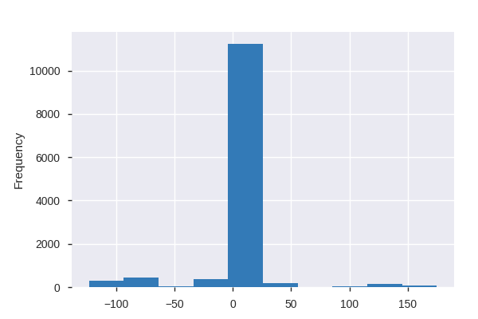

**Common Values**

| Value | Count | Frequency (%) |  |
| --- | --- | --- | --- |
| 21.0122287 | 730 | 5.4% |  |
| 12.537202 | 607 | 4.5% |  |
| -0.1254872 | 512 | 3.8% |  |
| 12.6390279 | 415 | 3.1% |  |
| 2.3522219 | 371 | 2.8% |  |
| -0.028045 | 360 | 2.7% |  |
| 9.1859243 | 354 | 2.6% |  |
| 10.3279036 | 336 | 2.5% |  |
| 12.4801802 | 280 | 2.1% |  |
| 12.291485 | 279 | 2.1% |  |
| Other values (343) | 8564 | 63.7% |  |
| (Missing) | 633 | 4.7% |  |

**Extreme Values**

Minimum 5 values

| Value | Count | Frequency (%) |  |
| --- | --- | --- | --- |
| -123.1139268 | 4 | 0.0% |  |
| -122.4194155 | 4 | 0.0% |  |
| -122.3320708 | 22 | 0.2% |  |
| -122.231635 | 3 | 0.0% |  |
| -122.2006786 | 6 | 0.0% |  |

Maximum 5 values

| Value | Count | Frequency (%) |  |
| --- | --- | --- | --- |
| 151.2265861 | 3 | 0.0% |  |
| 151.231124 | 2 | 0.0% |  |
| 151.2956646 | 5 | 0.0% |  |
| 153.0660163 | 1 | 0.0% |  |
| 174.7633315 | 2 | 0.0% |  |

TariffCode  
Categorical

| Distinct count | 348 |
| --- | --- |
| Unique (%) | 2.6% |
| Missing (%) | 5.8% |
| Missing (n) | 780 |

| 6109.10.00 | 1348 |
| --- | --- |
| 0000.00.00 | 1152 |
| 6110.20.20 | 704 |
| Other values (344) | 9457 |
| (Missing) | 780 |

Toggle details

| Value | Count | Frequency (%) |  |
| --- | --- | --- | --- |
| 6109.10.00 | 1348 | 10.0% |  |
| 0000.00.00 | 1152 | 8.6% |  |
| 6110.20.20 | 704 | 5.2% |  |
| 6404.11.20 | 624 | 4.6% |  |
| 6203.42.40 | 585 | 4.4% |  |
| 4202.21.90 | 524 | 3.9% |  |
| 6404.11.90 | 511 | 3.8% |  |
| 6403.59.90 | 364 | 2.7% |  |
| 6110.11.00 | 276 | 2.1% |  |
| 6205.20.20 | 206 | 1.5% |  |
| Other values (337) | 6367 | 47.4% |  |
| (Missing) | 780 | 5.8% |  |

Correlations

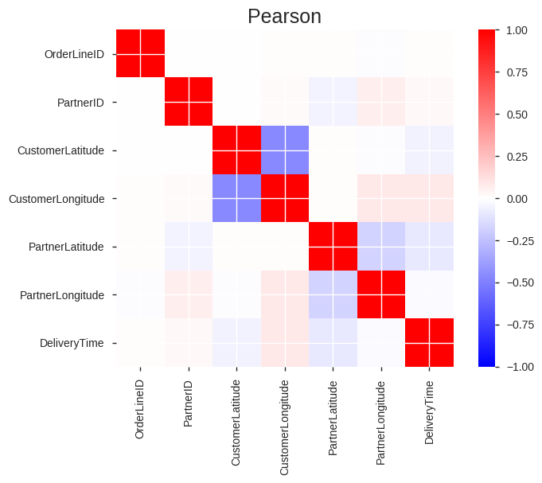

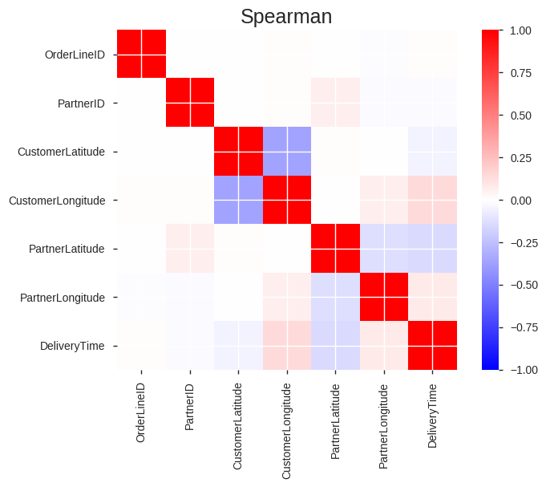

Sample

|  | OrderLineID | OrderCodeID | PartnerID | CustomerCountry | CustomerCity | CustomerLatitude | CustomerLongitude | PartnerLatitude | PartnerLongitude | PartnerCountry | PartnerCity | DeliveryType | IsHazmat | TariffCode | DdpCategory | DdpSubcategory | Category1stLevel | Category2ndLevel | OrderDate | DeliveryTime |
| --- | --- | --- | --- | --- | --- | --- | --- | --- | --- | --- | --- | --- | --- | --- | --- | --- | --- | --- | --- | --- |
| 0 | 3585 | BBR10944434 | 9949 | Singapore | singapore | 1.280094 | 103.850949 | 51.331300 | 0.445068 | United Kingdom | Snodland | Express | No | 6109.10.00 | Clothing & Accessories | T-shirts singlets and other vests | Clothing | T-Shirts & Vests | 2017-05-11 08:39:40 | 4.04 |
| 1 | 1339 | BIR4931334 | 9673 | China | Beijing | 39.904030 | 116.407526 | 45.962640 | 12.655136 | Italy | Pordenone | Express | No | 4202.12.80 | Bags & similar | Trunks suitcases vanity cases executive-cas... | Bags | Backpacks | 2016-02-04 13:19:13 | 9.88 |
| 2 | 4448 | GRM6588384 | 9383 | United Kingdom | Altrincham | 53.390180 | -2.350904 | 41.872389 | 12.480180 | Italy | Rome | Standard | No | 6203.43.20 | Clothing & Accessories | Trousers overalls shorts | Clothing | All in One | 2016-07-12 12:08:41 | 6.88 |
| 3 | 1817 | MBT12633964 | 9579 | Bulgaria | Varna | 43.204665 | 27.910542 | 45.676552 | 9.236743 | Italy | CARATE BRIANZA | Express | No | 0000.00.00 | default value | NaN | Bags | Tote Bags | 2017-07-26 13:30:31 | 5.83 |
| 4 | 18475 | PRT9869856 | 9671 | Denmark | Aalborg | 57.048819 | 9.921747 | 44.057082 | 12.564600 | Italy | Rimini | Standard | No | 6109.10.00 | Clothing & Accessories | T-shirts singlets and other vests | Clothing | T-Shirts & Vests | 2017-03-09 09:53:18 | 6.25 |

```python
pr
```

```python
# Analyzing missing Partner information
df[df.PartnerLatitude.isnull()]
```

|  | OrderLineID | OrderCodeID | PartnerID | CustomerCountry | CustomerCity | CustomerLatitude | CustomerLongitude | PartnerLatitude | PartnerLongitude | PartnerCountry | PartnerCity | DeliveryType | IsHazmat | TariffCode | DdpCategory | DdpSubcategory | Category1stLevel | Category2ndLevel | OrderDate | DeliveryTime |
| --- | --- | --- | --- | --- | --- | --- | --- | --- | --- | --- | --- | --- | --- | --- | --- | --- | --- | --- | --- | --- |
| 5 | 10390 | MJR10985969 | 10602 | Korea Republic of | Dogok2-dong Kangnam-gu | NaN | NaN | NaN | NaN | Italy | BELLIZZI (SA) | Express | No | 6109100000 | Kids' Clothing & Accessories | T-shirts singlets and other vests | Girls Clothing | Tops | 2017-05-14 03:34:46 | 3.46 |
| 18 | 7703 | TZF9435254 | 9728 | Hong Kong | Hong Kong | 22.396428 | 114.109497 | NaN | NaN | Italy | ALBANO SANT ALESSANDRO | Express | No | 6109100000 | Kids' Clothing & Accessories | T-shirts singlets and other vests | Boys Clothing | Tops | 2017-02-09 08:58:45 | 2.04 |
| 27 | 1813 | DOP6929237 | 9954 | Germany | Kempten | 47.733333 | 10.316667 | NaN | NaN | Italy | Funo Di Argelato | Standard | No | 6110.20.20 | Clothing & Accessories | Jerseys pullovers cardigans waistcoats and ... | Clothing | Sweaters & Knitwear | 2016-08-10 21:22:44 | 5.62 |
| 28 | 14370 | DVC15552116 | 9921 | Russian Federation | Saint Petersburg | 59.934280 | 30.335099 | NaN | NaN | Italy | SANT ANASTASIA | Express | No | 6110.11.00 | Clothing & Accessories | Jerseys pullovers cardigans waistcoats and ... | Clothing | Knitwear | 2017-12-08 08:24:16 | 6.08 |
| 119 | 1072 | TZF5060027 | 9728 | Hungary | Nyíregyháza | NaN | NaN | NaN | NaN | Italy | ALBANO SANT ALESSANDRO | Standard | No | 6214.10.10 | Clothing & Accessories | Shawls scarves mufflers mantillas veils an... | Accessories | Scarves | 2016-02-13 10:50:47 | 5.21 |
| 172 | 1032 | DOP5861489 | 9954 | United States | salt lake city | 40.760779 | -111.891047 | NaN | NaN | Italy | Funo Di Argelato | Express | No | 6109.10.00 | Clothing & Accessories | T-shirts singlets and other vests | Clothing | Polo Shirts | 2016-05-18 00:44:23 | 5.42 |
| 181 | 14394 | TZF7914446 | 9728 | Germany | gmund | 47.750718 | 11.734959 | NaN | NaN | Italy | ALBANO SANT ALESSANDRO | Standard | No | 0000.00.00 | default value | NaN | Clothing | Tops | 2016-11-16 09:37:24 | 0.96 |
| 187 | 5497 | DVC16739877 | 9921 | Cyprus | Ayia Napa | 34.983333 | 34.000000 | NaN | NaN | Italy | SANT ANASTASIA | Express | No | 6109.10.00 | Clothing & Accessories | T-shirts singlets and other vests | Clothing | T-Shirts & Vests | 2018-01-13 04:03:00 | 4.46 |
| 201 | 11278 | TZF12654562 | 9728 | Australia | St Leonards | -33.823443 | 151.193583 | NaN | NaN | Italy | ALBANO SANT ALESSANDRO | Express | No | 4202.21.90 | Bags & similar | Handbags whether or not with shoulder strap ... | Bags | Satchels & Cross Body Bags | 2017-07-27 15:26:20 | 3.96 |
| 203 | 16569 | DVO10141102 | 9474 | United States | irvine | 33.683947 | -117.794694 | NaN | NaN | Italy | Santa Maria a monte | Express | No | 6109.10.00 | Clothing & Accessories | T-shirts singlets and other vests | Clothing | T-Shirts & Vests | 2017-03-26 00:45:49 | 4.46 |
| 276 | 7117 | ENN9875303 | 10158 | Hong Kong | Hong Kong | 22.396428 | 114.109497 | NaN | NaN | Greece | PHILOTHEI | Express | No | 6206.30.30 | Clothing & Accessories | Blouses shirts and shirt-blouses | Clothing | Tops | 2017-03-09 15:15:02 | 1.04 |
| 293 | 13606 | DOP15966221 | 9954 | United Kingdom | London | 51.508515 | -0.125487 | NaN | NaN | Italy | Funo Di Argelato | Standard | No | 6203.32.20 | Clothing & Accessories | Jackets and blazers | Clothing | Jackets | 2017-12-26 21:05:45 | 7.54 |
| 332 | 9789 | MJR10780708 | 10602 | United States | Sacramento | 38.581572 | -121.494400 | NaN | NaN | Italy | BELLIZZI (SA) | Express | No | 6109100000 | Kids' Clothing & Accessories | T-shirts singlets and other vests | Boys Clothing | Tops | 2017-05-01 09:32:09 | 3.08 |
| 345 | 11945 | NOK17334486 | 10433 | Korea Republic of | seoul | 37.531893 | 126.919116 | NaN | NaN | Italy | FUNO DI ARGELATO (BO) | Express | No | 6103.43.15 | Clothing & Accessories | Trousers overalls shorts | Activewear | Sport Trousers | 2018-02-08 03:21:06 | 4.29 |
| 370 | 250 | TZF11563793 | 9728 | Mexico | MEXICO | 19.432608 | -99.133208 | NaN | NaN | Italy | ALBANO SANT ALESSANDRO | Express | No | 6110.20.20 | Clothing & Accessories | Jerseys pullovers cardigans waistcoats and ... | Clothing | Knitwear | 2017-06-12 14:31:09 | 6.79 |
| 391 | 17497 | DVC15812598 | 9921 | Australia | South Morang | -37.651339 | 145.089104 | NaN | NaN | Italy | SANT ANASTASIA | Express | No | 6403.99.60 | Footwear with outer soles of rubber plastics ... | Other footwear | Shoes | Low-Tops | 2017-12-19 02:10:06 | 5.38 |
| 418 | 4615 | DVO13681780 | 9474 | United Kingdom | London | 51.508515 | -0.125487 | NaN | NaN | Italy | Santa Maria a monte | Standard | No | 0000.00.00 | default value | NaN | Clothing | Jackets | 2017-10-05 06:43:04 | 5.38 |
| 423 | 18986 | TZF13506289 | 9728 | Italy | POMEZIA | 41.669337 | 12.502344 | NaN | NaN | Italy | ALBANO SANT ALESSANDRO | Express | No | 6110.11.00 | Clothing & Accessories | Jerseys pullovers cardigans waistcoats and ... | Clothing | Knitwear | 2017-09-23 10:08:57 | 3.21 |
| 432 | 13833 | DOP16705410 | 9954 | Germany | bautzen | 51.182293 | 14.423775 | NaN | NaN | Italy | Funo Di Argelato | Standard | No | 4202.21.90 | Bags & similar | Handbags whether or not with shoulder strap ... | Bags | Shoulder Bags | 2018-01-12 16:49:59 | 4.71 |
| 487 | 9896 | DOP10189283 | 9954 | Korea Republic of | Mapogu | NaN | NaN | NaN | NaN | Italy | Funo Di Argelato | Express | No | 6103.42.10 | Clothing & Accessories | Trousers overalls shorts | Clothing | Trousers | 2017-03-28 15:56:02 | 2.88 |
| 507 | 7111 | DVO13655592 | 9474 | Russian Federation | moscow | 55.755826 | 37.617300 | NaN | NaN | Italy | Santa Maria a monte | Express | No | 6404.11.20 | Footwear with outer soles of rubber plastics ... | Footwear with outer soles of rubber or plastics | Shoes | Trainers | 2017-10-03 13:06:59 | 3.12 |
| 510 | 7327 | TZF7001109 | 9728 | Russian Federation | Moscow | 55.755826 | 37.617300 | NaN | NaN | Italy | ALBANO SANT ALESSANDRO | Express | No | 6110.30.30 | Clothing & Accessories | Jerseys pullovers cardigans waistcoats and ... | Clothing | Knitwear | 2016-08-19 11:03:13 | 6.17 |
| 556 | 8818 | 13M12816401 | 10122 | United States | East Lansing | 42.736979 | -84.483865 | NaN | NaN | Italy | IGEA MARINA | Express | No | 6206.30.30 | Clothing & Accessories | Blouses shirts and shirt-blouses | Clothing | Tops | 2017-08-07 06:05:51 | 3.25 |
| 565 | 340 | DVO9808142 | 9474 | United States | Lansdale | 40.241495 | -75.283786 | NaN | NaN | Italy | Santa Maria a monte | Express | No | 6109.10.00 | Clothing & Accessories | T-shirts singlets and other vests | Clothing | T-Shirts & Vests | 2017-03-06 03:15:02 | 3.46 |
| 593 | 11579 | DOP10907311 | 9954 | China | 105 | NaN | NaN | NaN | NaN | Italy | Funo Di Argelato | Express | No | 6110.20.20 | Clothing & Accessories | Jerseys pullovers cardigans waistcoats and ... | Clothing | Sweaters & Knitwear | 2017-05-09 11:49:55 | 8.04 |
| 610 | 6266 | ILF7367632 | 9904 | Spain | Inca | 39.717774 | 2.907547 | NaN | NaN | Italy | AVELINO | Standard | No | 0000.00.00 | default value | NaN | Clothing | Sweaters & Knitwear | 2016-09-28 16:38:34 | 5.88 |
| 621 | 2608 | LAH14252118 | 10280 | Singapore | singapore | 1.280094 | 103.850949 | NaN | NaN | Greece | NEA KIFISIA | Express | No | 6201110000 | Kids' Clothing & Accessories | Coats: overcoats raincoat cape cloaks and s... | Girls Clothing | Coats | 2017-11-04 14:46:39 | 5.04 |
| 648 | 17777 | RCS11396905 | 10624 | U.A.E. | los angeles | 34.052234 | -118.243685 | NaN | NaN | France | romans sur isere | Express | No | 6403.59.30 | Footwear with outer soles of rubber plastics ... | Other footwear with outer soles of leather | Shoes | Sandals | 2017-06-04 06:34:17 | 8.33 |
| 675 | 11454 | CLE10966018 | 10238 | Azerbaijan | Baku | 40.434950 | 49.867623 | NaN | NaN | Italy | Rutigliano | Express | No | 6104420000 | Kids' Clothing & Accessories | Dresses | Girls Clothing | Dresses | 2017-05-12 15:28:46 | 5.08 |
| 688 | 19896 | TZF16680065 | 9728 | United States | San Marino | 34.121397 | -118.106459 | NaN | NaN | Italy | ALBANO SANT ALESSANDRO | Express | No | 4205.00.80 | Other articles of leather or of composition le... | Other | Accessories | Keyrings & Chains | 2018-01-12 11:26:16 | 3.96 |
| ... | ... | ... | ... | ... | ... | ... | ... | ... | ... | ... | ... | ... | ... | ... | ... | ... | ... | ... | ... | ... |
| 12784 | 12468 | DVO11093960 | 9474 | Kyrgyzstan | Bishkek | 42.874722 | 74.612222 | NaN | NaN | Italy | Santa Maria a monte | Express | No | 6404.11.20 | Footwear with outer soles of rubber plastics ... | Footwear with outer soles of rubber or plastics | Shoes | Trainers | 2017-05-19 20:39:09 | 4.79 |
| 12792 | 2463 | DOP12668572 | 9954 | Germany | Berlin | 52.520007 | 13.404954 | NaN | NaN | Italy | Funo Di Argelato | Express | No | 6109.10.00 | Clothing & Accessories | T-shirts singlets and other vests | Clothing | T-Shirts & Vests | 2017-07-28 10:21:04 | 4.04 |
| 12798 | 19467 | TZF5096994 | 9728 | Singapore | SINGAPORE | 1.280094 | 103.850949 | NaN | NaN | Italy | ALBANO SANT ALESSANDRO | Express | No | 0000.00.00 | default value | NaN | Clothing | Polo Shirts | 2016-02-19 11:46:21 | 2.88 |
| 12824 | 7617 | DVC10704592 | 9921 | Italy | milan | 45.465422 | 9.185924 | NaN | NaN | Italy | SANT ANASTASIA | Standard | No | 6203.42.40 | Clothing & Accessories | Trousers overalls shorts | Clothing | Trousers | 2017-04-26 18:18:44 | 1.71 |
| 12837 | 2232 | ILF16018965 | 9904 | China | Kunming | 24.880095 | 102.832892 | NaN | NaN | Italy | AVELINO | Express | No | 0000.00.00 | default value | NaN | Clothing | Trousers | 2017-12-29 10:40:21 | 7.00 |
| 12866 | 19164 | KNT15909271 | 10311 | United States | Long Island City | 40.744679 | -73.948542 | NaN | NaN | Portugal | FAMOES | Express | No | 6111209000 | Babies' garments and clothing accessories | Babies' Other garments and clothing accessories | Baby Girl Clothing | Babywear | 2017-12-23 15:35:22 | 5.00 |
| 12871 | 7868 | KNT14967362 | 10311 | Hong Kong | Kowloon | 22.318567 | 114.179606 | NaN | NaN | Portugal | FAMOES | Express | No | 6110301500 | Kids' Clothing & Accessories | Jerseys pullovers cardigans waistcoats and ... | Boys Clothing | Tops | 2017-11-24 05:33:18 | 8.17 |
| 12906 | 13157 | TZF5869747 | 9728 | United States | philadelphia | 39.952335 | -75.163789 | NaN | NaN | Italy | ALBANO SANT ALESSANDRO | Express | No | 6205.20.20 | Clothing & Accessories | Shirts | Clothing | Shirts | 2016-05-18 19:39:32 | 4.62 |
| 12925 | 13901 | DOP15758111 | 9954 | United Kingdom | Leicester | 52.636878 | -1.139759 | NaN | NaN | Italy | Funo Di Argelato | Standard | No | 6109.90.10 | Clothing & Accessories | T-shirts singlets and other vests | Activewear | Sport Tops | 2017-12-16 21:06:12 | 4.62 |
| 12944 | 18087 | DVC11723855 | 9921 | Japan | NERIMA KU - SHIMOSHAKUJII | NaN | NaN | NaN | NaN | Italy | SANT ANASTASIA | Express | No | 4202.22.60 | Bags & similar | Handbags whether or not with shoulder strap ... | Bags | Shoulder Bags | 2017-06-20 04:05:21 | 3.25 |
| 12969 | 14976 | TZF9537259 | 9728 | Cambodia | Phnom Penh | 11.544873 | 104.892167 | NaN | NaN | Italy | ALBANO SANT ALESSANDRO | Express | No | 6214.20.00 | Clothing & Accessories | Shawls scarves mufflers mantillas veils an... | Accessories | Scarves | 2017-02-16 15:31:58 | 4.00 |
| 12987 | 11246 | DOP12106992 | 9954 | Italy | camaiore | 43.942140 | 10.296908 | NaN | NaN | Italy | Funo Di Argelato | Standard | No | 6109.10.00 | Clothing & Accessories | T-shirts singlets and other vests | Clothing | T-Shirts & Vests | 2017-07-10 10:31:22 | 3.04 |
| 12997 | 9984 | DVO6357287 | 9474 | Estonia | Maardu | 59.466977 | 24.979903 | NaN | NaN | Italy | Santa Maria a monte | Express | No | 6403.99.40 | Footwear with outer soles of rubber plastics ... | Other footwear | Shoes | Sandals | 2016-06-27 11:04:02 | 2.17 |
| 12999 | 19579 | DOP15106089 | 9954 | United States | Allendale | 33.007934 | -81.308441 | NaN | NaN | Italy | Funo Di Argelato | Express | No | 6404.11.90 | Footwear with outer soles of rubber plastics ... | Footwear with outer soles of rubber or plastics | Shoes | Low-Tops | 2017-11-24 23:14:58 | 5.62 |
| 13027 | 6115 | DVO8004081 | 9474 | United States | Novato | 38.107420 | -122.569703 | NaN | NaN | Italy | Santa Maria a monte | Express | No | 0000.00.00 | default value | NaN | Clothing | Skirts | 2016-11-22 07:30:14 | 3.42 |
| 13029 | 455 | COE17851105 | 10468 | United States | Portland | 45.523452 | -122.676207 | NaN | NaN | Japan | HIGASHIMURAYAMA GUN | Express | No | 6103.32.00 | Clothing & Accessories | Jackets and blazers | Clothing | Jackets | 2018-02-28 05:57:22 | 5.17 |
| 13035 | 10553 | TZF17748488 | 9728 | Kuwait | Kaifan | 29.333333 | 47.966667 | NaN | NaN | Italy | ALBANO SANT ALESSANDRO | Express | No | 6109100000 | Kids' Clothing & Accessories | T-shirts singlets and other vests | Boys Clothing | Tops | 2018-02-24 16:01:40 | 5.79 |
| 13046 | 9536 | DOP15041804 | 9954 | Hong Kong | Hong Kong | 22.396428 | 114.109497 | NaN | NaN | Italy | Funo Di Argelato | Express | No | 6110.20.20 | Clothing & Accessories | Jerseys pullovers cardigans waistcoats and ... | Clothing | Tops | 2017-11-24 14:54:38 | 5.92 |
| 13050 | 11699 | TZF16943813 | 9728 | Denmark | Holstebro | 56.361534 | 8.621727 | NaN | NaN | Italy | ALBANO SANT ALESSANDRO | Standard | No | 0000.00.00 | default value | NaN | Clothing | T-Shirts & Vests | 2018-01-21 10:12:44 | 5.00 |
| 13059 | 17760 | TZF17283367 | 9728 | Singapore | singapore | 1.280094 | 103.850949 | NaN | NaN | Italy | ALBANO SANT ALESSANDRO | Express | No | 6110.20.20 | Clothing & Accessories | Jerseys pullovers cardigans waistcoats and ... | Clothing | Sweaters & Knitwear | 2018-02-06 02:35:10 | 4.67 |
| 13062 | 17075 | DVC12485806 | 9921 | Hong Kong | Hong kong | 22.396428 | 114.109497 | NaN | NaN | Italy | SANT ANASTASIA | Express | No | 6404.20.60 | Footwear with outer soles of rubber plastics ... | Footwear with outer soles of leather or compos... | Shoes | Mules | 2017-07-17 01:17:13 | 2.42 |
| 13082 | 4536 | MJR16878284 | 10602 | Colombia | Medellín | NaN | NaN | NaN | NaN | Italy | BELLIZZI (SA) | Express | No | 6111209000 | Babies' garments and clothing accessories | Babies' T-shirts singlets and similar garment... | Baby Boy Clothing | Tops | 2018-01-18 06:27:40 | 4.21 |
| 13089 | 6617 | DOP7940798 | 9954 | Czech Republic | jihlava | NaN | NaN | NaN | NaN | Italy | Funo Di Argelato | Express | No | NaN | NaN | NaN | Clothing | Sweaters & Knitwear | 2016-11-18 15:18:55 | 4.92 |
| 13157 | 12776 | TZF5084864 | 9728 | U.A.E. | Dubai | 25.047664 | 55.181741 | NaN | NaN | Italy | ALBANO SANT ALESSANDRO | Express | No | 6403.59.30 | Footwear with outer soles of rubber plastics ... | Other footwear with outer soles of leather | Shoes | Pumps | 2016-02-17 13:15:45 | 2.79 |
| 13183 | 4545 | DVO9666921 | 9474 | United Kingdom | Liverpool | 53.408371 | -2.991573 | NaN | NaN | Italy | Santa Maria a monte | Standard | No | 6202.13.10 | Clothing & Accessories | Coats: overcoats raincoat cape cloak ski j... | Clothing | Jackets | 2017-02-25 17:09:35 | 5.96 |
| 13243 | 18137 | DVO8252276 | 9474 | United States | Long Island City | 40.744679 | -73.948542 | NaN | NaN | Italy | Santa Maria a monte | Express | No | 6404.11.20 | Footwear with outer soles of rubber plastics ... | Footwear with outer soles of rubber or plastics | Shoes | Trainers | 2016-11-30 14:39:53 | 2.00 |
| 13245 | 8271 | DVO5938975 | 9474 | United States | brooklyn | 40.692778 | -73.990278 | NaN | NaN | Italy | Santa Maria a monte | Express | No | NaN | NaN | NaN | Accessories | Hats | 2016-05-24 06:10:55 | 1.17 |
| 13336 | 8658 | TZF6080198 | 9728 | China | Beijing | 39.904030 | 116.407526 | NaN | NaN | Italy | ALBANO SANT ALESSANDRO | Express | No | 6205.20.20 | Clothing & Accessories | Shirts | Clothing | Shirts | 2016-06-02 19:07:36 | 3.88 |
| 13354 | 10900 | TZF11006022 | 9728 | Japan | Himeji | 34.815149 | 134.685353 | NaN | NaN | Italy | ALBANO SANT ALESSANDRO | Express | No | 6109.10.00 | Clothing & Accessories | T-shirts singlets and other vests | Clothing | T-Shirts & Vests | 2017-05-15 13:59:08 | 2.92 |
| 13370 | 6521 | TZF6881145 | 9728 | Australia | Sydney | -33.867487 | 151.206990 | NaN | NaN | Italy | ALBANO SANT ALESSANDRO | Express | No | 6403.99.40 | Footwear with outer soles of rubber plastics ... | Other footwear | Shoes | Sandals | 2016-08-04 14:29:55 | 3.75 |

633 rows × 20 columns

```python
# Analyzing missing Partner information
df[(df.PartnerCountry.isnull()) & (df.PartnerLatitude.isnull())]
```

|  | OrderLineID | OrderCodeID | PartnerID | CustomerCountry | CustomerCity | CustomerLatitude | CustomerLongitude | PartnerLatitude | PartnerLongitude | PartnerCountry | PartnerCity | DeliveryType | IsHazmat | TariffCode | DdpCategory | DdpSubcategory | Category1stLevel | Category2ndLevel | OrderDate | DeliveryTime |
| --- | --- | --- | --- | --- | --- | --- | --- | --- | --- | --- | --- | --- | --- | --- | --- | --- | --- | --- | --- | --- |

```python
# Analyzing missing Customer information
df[df.CustomerLatitude.isnull()]
```

|  | OrderLineID | OrderCodeID | PartnerID | CustomerCountry | CustomerCity | CustomerLatitude | CustomerLongitude | PartnerLatitude | PartnerLongitude | PartnerCountry | PartnerCity | DeliveryType | IsHazmat | TariffCode | DdpCategory | DdpSubcategory | Category1stLevel | Category2ndLevel | OrderDate | DeliveryTime |
| --- | --- | --- | --- | --- | --- | --- | --- | --- | --- | --- | --- | --- | --- | --- | --- | --- | --- | --- | --- | --- |
| 5 | 10390 | MJR10985969 | 10602 | Korea Republic of | Dogok2-dong Kangnam-gu | NaN | NaN | NaN | NaN | Italy | BELLIZZI (SA) | Express | No | 6109100000 | Kids' Clothing & Accessories | T-shirts singlets and other vests | Girls Clothing | Tops | 2017-05-14 03:34:46 | 3.46 |
| 15 | 10418 | OFC10834361 | 9869 | Germany | Düsseldorf | NaN | NaN | 43.304849 | 13.721835 | Italy | CIVITANOVA MARCHE | Standard | No | 6403.59.30 | Footwear with outer soles of rubber plastics ... | Other footwear with outer soles of leather | Shoes | Sandals | 2017-05-04 07:43:48 | 4.04 |
| 23 | 11840 | SAN11567056 | 9006 | Malaysia | Nusajaya | NaN | NaN | 43.771033 | 11.248001 | Italy | Firenze | Express | No | 6203.42.40 | Clothing & Accessories | Trousers overalls shorts | Clothing | Trousers | 2017-06-12 16:50:58 | 3.79 |
| 32 | 4651 | BRH12614685 | 10361 | Croatia | Rab | NaN | NaN | 51.652766 | -0.028045 | United Kingdom | Brimsdown | Express | No | 6104.53.20 | Clothing & Accessories | Skirts | Clothing | Skirts | 2017-07-25 13:42:18 | 3.00 |
| 37 | 3132 | AQU9772965 | 10168 | Nigeria | Ikoyi | NaN | NaN | 42.061382 | -1.606317 | Spain | Tudela | Express | No | 6204.43.40 | Clothing & Accessories | Dresses | Clothing | Dresses | 2017-03-04 00:20:38 | 4.42 |
| 42 | 5939 | BRH18117541 | 10361 | United Kingdom | Bham | NaN | NaN | 51.652766 | -0.028045 | United Kingdom | Brimsdown | Express | No | 6403.99.90 | Footwear with outer soles of rubber plastics ... | Other footwear | Shoes | Trainers | 2018-03-08 21:44:49 | 3.50 |
| 44 | 96 | GNB13824322 | 9838 | Kosovo | prishtina | NaN | NaN | 45.482741 | 10.178901 | Italy | FLERO | Express | No | 6110.20.20 | Clothing & Accessories | Jerseys pullovers cardigans waistcoats and ... | Clothing | Tops | 2017-10-13 15:39:03 | 4.92 |
| 48 | 3694 | HAC12709252 | 10697 | United States | Holmes Beach | NaN | NaN | 40.733518 | -73.780145 | United States | fresh meadows | Express | No | 4202.39.90 | Bags & similar | Articles of a kind normally carried in the poc... | Lifestyle | Phone Computer & Gadgets | 2017-07-30 21:29:47 | 4.67 |
| 59 | 10816 | GNB17180050 | 9838 | Germany | Mülheim | NaN | NaN | 45.482741 | 10.178901 | Italy | FLERO | Standard | No | 4202.29.90 | Bags & similar | Handbags whether or not with shoulder strap ... | Bags | Tote Bags | 2018-02-01 10:09:34 | 5.08 |
| 66 | 18402 | TOX15832217 | 10797 | Czech Republic | Buchlovice | NaN | NaN | 54.687156 | 25.279651 | Lithuania | Vilnius | Express | No | 4202.31.60 | Bags & similar | Articles of a kind normally carried in the poc... | Accessories | Wallets & Cardholders | 2017-12-19 20:10:17 | 2.67 |
| 76 | 13065 | AAM15432470 | 9846 | Germany | Köln | NaN | NaN | 48.666020 | 2.557690 | France | combs la ville | Standard | No | 6109.10.00 | Clothing & Accessories | T-shirts singlets and other vests | Clothing | T-Shirts & Vests | 2017-12-03 18:13:14 | 3.62 |
| 78 | 1297 | NID10525471 | 9452 | Azerbaijan | Bakü | NaN | NaN | 41.072348 | 14.331134 | Italy | Caserta | Express | No | 6205.20.20 | Clothing & Accessories | Shirts | Clothing | Shirts | 2017-04-17 11:41:10 | 4.12 |
| 85 | 13270 | STF12732554 | 9336 | Greece | Platamonas | NaN | NaN | 38.017618 | 12.537202 | Italy | TRAPANI | Express | No | 4202.21.90 | Bags & similar | Handbags whether or not with shoulder strap ... | Bags | Shoulder Bags | 2017-08-01 10:19:47 | 3.38 |
| 87 | 19079 | THW12013916 | 10080 | Korea Republic of | Seo-gu Gwangju | NaN | NaN | 34.052234 | -118.243685 | United States | Los Angeles | Express | No | 6206.10.00 | Clothing & Accessories | Blouses shirts and shirt-blouses | Clothing | Dresses | 2017-07-05 16:02:42 | 5.71 |
| 89 | 5957 | PAS9228771 | 10188 | Russian Federation | Peterburi | NaN | NaN | 52.954783 | -1.158109 | United Kingdom | Nottingham | Express | No | NaN | NaN | NaN | Clothing | Underwear & Socks | 2017-01-24 04:15:11 | 2.46 |
| 93 | 1740 | C2117732589 | 9918 | Japan | SHIBUYA KU - MOTOYOYOGICHO | NaN | NaN | 1.280094 | 103.850949 | Singapore | Singapore | Express | No | 6203.42.40 | Clothing & Accessories | Trousers overalls shorts | Clothing | Trousers | 2018-02-24 03:11:21 | 4.54 |
| 94 | 1456 | TSS10965610 | 9053 | Korea Republic of | Daejeon Seogu | NaN | NaN | 45.808060 | 9.085176 | Italy | Como | Express | No | 6109.10.00 | Clothing & Accessories | T-shirts singlets and other vests | Clothing | T-Shirts & Vests | 2017-05-12 14:49:28 | 6.04 |
| 110 | 13472 | K2116438104 | 10033 | Korea Republic of | JungGu | NaN | NaN | 1.280094 | 103.850949 | Singapore | Singapore | Express | No | 6204522000 | Kids' Clothing & Accessories | Skirts | Girls Clothing | Skirts | 2018-01-09 16:00:20 | 6.04 |
| 119 | 1072 | TZF5060027 | 9728 | Hungary | Nyíregyháza | NaN | NaN | NaN | NaN | Italy | ALBANO SANT ALESSANDRO | Standard | No | 6214.10.10 | Clothing & Accessories | Shawls scarves mufflers mantillas veils an... | Accessories | Scarves | 2016-02-13 10:50:47 | 5.21 |
| 126 | 13871 | JAN17142561 | 9693 | Portugal | S.Julião do Tojal | NaN | NaN | 41.545449 | -8.426507 | Portugal | Braga | Express | No | 6203.42.40 | Clothing & Accessories | Trousers overalls shorts | Clothing | Denim | 2018-01-30 15:12:22 | 2.83 |
| 152 | 1484 | BRO5333523 | 9359 | Kuwait | Asimah surra | NaN | NaN | 51.508515 | -0.125487 | United Kingdom | London | Express | No | 6204.43.40 | Clothing & Accessories | Dresses | Clothing | Dresses | 2016-03-22 20:33:36 | 3.54 |
| 166 | 3375 | OOO15751763 | 9475 | Korea Republic of | busansi | NaN | NaN | 44.801485 | 10.327904 | Italy | Parma | Express | No | 6110.12.10 | Clothing & Accessories | Jerseys pullovers cardigans waistcoats and ... | Clothing | Sweaters & Knitwear | 2017-12-16 15:26:23 | 10.04 |
| 167 | 1252 | PRT10187686 | 9671 | China | Ha'erbin | NaN | NaN | 44.057082 | 12.564600 | Italy | Rimini | Express | No | 6110.11.00 | Clothing & Accessories | Jerseys pullovers cardigans waistcoats and ... | Clothing | Sweaters & Knitwear | 2017-03-28 14:18:39 | 9.88 |
| 170 | 2329 | D2213265770 | 10230 | Hong Kong | HONGKONG SHATIN | NaN | NaN | 40.682441 | 14.768096 | Italy | Salerno | Express | No | 6110.20.20 | Clothing & Accessories | Jerseys pullovers cardigans waistcoats and ... | Clothing | Sweaters & Knitwear | 2017-09-07 18:02:53 | 2.83 |
| 173 | 15239 | DPR11858109 | 9334 | Brazil | Florianópolis | NaN | NaN | 40.464361 | 17.247030 | Italy | Taranto | Express | No | 6202.13.40 | Clothing & Accessories | Coats: overcoats raincoat cape cloak ski j... | Clothing | Jackets | 2017-06-27 03:18:09 | 6.38 |
| 175 | 8870 | BRO10165388 | 9359 | France | Arthaz Pont Notre Dame | NaN | NaN | 51.508515 | -0.125487 | United Kingdom | London | Standard | No | 6404.11.90 | Footwear with outer soles of rubber plastics ... | Footwear with outer soles of rubber or plastics | Shoes | Trainers | 2017-03-27 11:54:25 | 3.92 |
| 191 | 6565 | MBT5501844 | 9579 | Korea Republic of | seodaemun | NaN | NaN | 45.676552 | 9.236743 | Italy | CARATE BRIANZA | Express | No | 0000.00.00 | default value | NaN | Clothing | Jackets | 2016-04-09 16:51:52 | 4.62 |
| 213 | 14027 | LSH5214873 | 9529 | Japan | awajimachi cyuoku osaka-shi | NaN | NaN | 45.838056 | 12.217222 | Italy | COLFOSCO DI SUSEGANA (TV) | Express | No | 6110.90.10 | Clothing & Accessories | Jerseys pullovers cardigans waistcoats and ... | Clothing | Tops | 2016-03-08 23:35:37 | 5.62 |
| 222 | 10760 | ODD13070420 | 9485 | China | Chaoyang District Beijing | NaN | NaN | 40.692778 | -73.990278 | United States | Brooklyn | Express | No | 6103.49.10 | Clothing & Accessories | Trousers overalls shorts | Clothing | Knitwear | 2017-08-25 16:00:18 | 10.00 |
| 247 | 2863 | STU11508165 | 9564 | China | Zaozhuang | NaN | NaN | 45.047375 | 9.686581 | Italy | Piacenza | Express | No | 0000.00.00 | default value | NaN | Shoes | Pumps | 2017-06-09 16:03:44 | 8.71 |
| ... | ... | ... | ... | ... | ... | ... | ... | ... | ... | ... | ... | ... | ... | ... | ... | ... | ... | ... | ... | ... |
| 13161 | 9086 | CAJ5855327 | 10029 | Korea Republic of | hannam-dong 11-132 Yongsan-gu | NaN | NaN | 39.298263 | 16.253736 | Italy | cosenza | Express | No | 6109100000 | Kids' Clothing & Accessories | T-shirts singlets and other vests | Boys Clothing | Tops | 2016-05-17 12:36:57 | 6.00 |
| 13176 | 14970 | PRI7078906 | 9317 | Japan | irima-cho choufu-shi | NaN | NaN | 37.851637 | 15.285313 | Italy | Taormina | Express | No | NaN | NaN | NaN | Clothing | Shirts | 2016-08-28 08:29:46 | 6.08 |
| 13179 | 1218 | NCK11857812 | 10411 | Korea Republic of | seochoku seocho4dong | NaN | NaN | 48.135125 | 11.581981 | Germany | Munchen | Express | No | 6104420000 | Kids' Clothing & Accessories | Dresses | Girls Clothing | Dresses | 2017-06-27 02:41:06 | 3.38 |
| 13186 | 672 | YUS14896803 | 9661 | Denmark | Hillerød | NaN | NaN | 40.416775 | -3.703790 | Spain | Madrid | Express | No | 6115.29.80 | Clothing & Accessories | Pantyhose tights | Clothing | Underwear & Socks | 2017-11-23 19:20:53 | 4.58 |
| 13187 | 6061 | N3010164303 | 10017 | Japan | Kitagun | NaN | NaN | 45.465422 | 9.185924 | Italy | MILAN | Express | No | 0000.00.00 | default value | NaN | Clothing | Tops | 2017-03-27 10:22:54 | 4.00 |
| 13199 | 5384 | VS116437278 | 11025 | Japan | NAGOYA SHI NISHI KU - NAZUKACHO | NaN | NaN | 43.722839 | 10.401689 | Italy | Pisa | Express | No | 6104.42.00 | Clothing & Accessories | Dresses | Clothing | Dresses | 2018-01-09 15:55:42 | 6.96 |
| 13224 | 5270 | DOG8215332 | 9258 | Bermuda | Smiths | NaN | NaN | 38.115688 | 13.361267 | Italy | Palermo | Express | No | 4202.22.80 | Bags & similar | Handbags whether or not with shoulder strap ... | Bags | Tote Bags | 2016-11-28 15:59:45 | 13.83 |
| 13227 | 15263 | CHR5625642 | 9114 | Lebanon | Meziara | NaN | NaN | 51.278708 | 0.521725 | United Kingdom | Kent | Express | No | 6206.30.30 | Clothing & Accessories | Blouses shirts and shirt-blouses | Clothing | Tops | 2016-04-22 17:53:47 | 5.75 |
| 13234 | 12209 | JLF11378785 | 9306 | Japan | SANO SHI - UEKAMICHO | NaN | NaN | 44.323287 | 12.291485 | Italy | savio | Express | No | 4202.29.90 | Bags & similar | Handbags whether or not with shoulder strap ... | Bags | Clutch Bags | 2017-06-03 05:01:06 | 5.58 |
| 13241 | 13408 | SAN9443061 | 9006 | Russian Federation | Syktyvkar | NaN | NaN | 43.771033 | 11.248001 | Italy | Firenze | Express | No | NaN | NaN | NaN | Clothing | T-Shirts & Vests | 2017-02-09 20:14:40 | 7.62 |
| 13252 | 19273 | ATN7221705 | 10015 | Kuwait | Kuwait Riqqa | NaN | NaN | 45.070312 | 7.686857 | Italy | Torino | Express | No | 0000.00.00 | default value | NaN | Shoes | Trainers | 2016-09-13 02:59:37 | 4.58 |
| 13258 | 10599 | TSS16805049 | 9053 | Japan | NISHINOMIYA SHI - KUDEGAYACHO | NaN | NaN | 45.808060 | 9.085176 | Italy | Como | Express | No | 6109100000 | Kids' Clothing & Accessories | T-shirts singlets and other vests | Boys Clothing | Tops | 2018-01-15 06:03:23 | 8.12 |
| 13279 | 14785 | CBM14066068 | 9496 | Ireland | Dublin 10 | NaN | NaN | 51.054342 | 3.717424 | Belgium | Gent | Express | No | 6109.10.00 | Clothing & Accessories | T-shirts singlets and other vests | Clothing | T-Shirts & Vests | 2017-10-25 20:08:52 | 1.71 |
| 13283 | 12930 | BCM14974052 | 9158 | Denmark | Støvring | NaN | NaN | 45.465422 | 9.185924 | Italy | Milano | Standard | No | 6403.99.60 | Footwear with outer soles of rubber plastics ... | Other footwear | Shoes | Trainers | 2017-11-24 06:31:48 | 5.21 |
| 13285 | 17775 | BLN12223997 | 9870 | Japan | SAKAI SHI KITA KU - MOZUMEKITACHO | NaN | NaN | 44.168903 | 8.341621 | Italy | Finale Ligure | Express | No | 6205.20.20 | Clothing & Accessories | Shirts | Clothing | Shirts | 2017-07-11 14:12:33 | 2.88 |
| 13291 | 2540 | BRH15754257 | 10361 | Germany | Köln | NaN | NaN | 51.652766 | -0.028045 | United Kingdom | Brimsdown | Standard | No | 6201.12.00 | Clothing & Accessories | Coats: overcoats raincoat cape cloaks and s... | Clothing | Coats | 2017-12-16 17:29:02 | 3.71 |
| 13320 | 15325 | OOO13617583 | 9475 | Japan | NISHINOMIYA SHI - KITANATSUGICHO | NaN | NaN | 44.801485 | 10.327904 | Italy | Parma | Express | No | 0000.00.00 | default value | NaN | Clothing | Trousers | 2017-10-01 00:53:42 | 4.38 |
| 13321 | 17016 | LIS16071447 | 9877 | Israel | atzmon segev | NaN | NaN | 47.999008 | 7.842104 | Germany | Freiburg | Express | No | 6106.20.20 | Clothing & Accessories | Blouses shirts and shirt-blouses | Clothing | Knitwear | 2018-01-01 16:11:10 | 5.71 |
| 13331 | 11106 | SCH7540654 | 9182 | Switzerland | schönenwerd | NaN | NaN | 48.135125 | 11.581981 | Germany | Munich | Express | No | NaN | NaN | NaN | Clothing | Sweaters & Knitwear | 2016-10-16 14:07:56 | 1.88 |
| 13333 | 5556 | AAM5889230 | 9846 | Japan | Kanazawa Yokohama | NaN | NaN | 48.666020 | 2.557690 | France | combs la ville | Express | No | 4202.31.60 | Bags & similar | Articles of a kind normally carried in the poc... | Accessories | Wallets & Cardholders | 2016-05-20 11:27:22 | 3.92 |
| 13338 | 11917 | VTK6265338 | 9462 | Austria | Kossen (Tirol) | NaN | NaN | 52.229676 | 21.012229 | Poland | warsaw | Express | No | 4202.21.90 | Bags & similar | Handbags whether or not with shoulder strap ... | Bags | Shoulder Bags | 2016-06-19 08:42:53 | 4.29 |
| 13355 | 14331 | LET18175158 | 9794 | France | Cournonsec | NaN | NaN | 50.629250 | 3.057256 | France | Lille | Standard | No | 6110.20.20 | Clothing & Accessories | Jerseys pullovers cardigans waistcoats and ... | Clothing | Sweaters & Knitwear | 2018-03-11 01:48:07 | 4.54 |
| 13362 | 516 | CHR18125425 | 9114 | Malaysia | Segamat | NaN | NaN | 51.278708 | 0.521725 | United Kingdom | Kent | Express | No | 6109.10.00 | Clothing & Accessories | T-shirts singlets and other vests | Clothing | Tops | 2018-03-09 06:01:28 | 5.25 |
| 13378 | 1876 | PAS8691828 | 10188 | Brazil | Edéia | NaN | NaN | 52.954783 | -1.158109 | United Kingdom | Nottingham | Express | No | NaN | NaN | NaN | Accessories | Hats | 2016-12-31 19:17:00 | 19.96 |
| 13383 | 12119 | RCA6473955 | 9274 | Spain | Gijón | NaN | NaN | 40.553201 | 14.222154 | Italy | CAPRI | Standard | No | 6404.11.20 | Footwear with outer soles of rubber plastics ... | Footwear with outer soles of rubber or plastics | Shoes | Trainers | 2016-07-08 09:56:09 | 10.96 |
| 13399 | 2986 | GAU8469192 | 9442 | Japan | Higashi-ku Sapporo-shi | NaN | NaN | 43.963318 | 12.738432 | Italy | CATTOLICA (RN) | Express | No | 6109.10.00 | Clothing & Accessories | T-shirts singlets and other vests | Clothing | T-Shirts & Vests | 2016-12-14 10:26:14 | 5.17 |
| 13424 | 19135 | JJW14554064 | 9523 | Belgium | Meeuwen | NaN | NaN | 51.508515 | -0.125487 | United Kingdom | London | Standard | No | 6206.10.00 | Clothing & Accessories | Blouses shirts and shirt-blouses | Clothing | Tops | 2017-11-14 20:44:58 | 2.50 |
| 13431 | 12288 | CBE7169200 | 9183 | Brazil | São Luís | NaN | NaN | 45.764043 | 4.835659 | France | Lyon | Express | No | 6109.90.10 | Clothing & Accessories | T-shirts singlets and other vests | Clothing | T-Shirts & Vests | 2016-09-07 09:39:38 | 5.25 |
| 13437 | 19304 | BRO6281695 | 9359 | Denmark | 6840 | NaN | NaN | 51.508515 | -0.125487 | United Kingdom | London | Standard | No | 6109.10.00 | Clothing & Accessories | T-shirts singlets and other vests | Clothing | T-Shirts & Vests | 2016-06-20 18:53:28 | 6.75 |
| 13439 | 13609 | BON8788582 | 9620 | Iraq | Sulaimani | NaN | NaN | 43.880847 | 10.775436 | Italy | Montecatini Terme | Express | No | 6202.13.10 | Clothing & Accessories | Coats: overcoats raincoat cape cloak ski j... | Clothing | Coats | 2017-01-08 21:48:46 | 6.67 |

1436 rows × 20 columns

```python
# Analyzing missing Customer information
df[(df.CustomerCountry.isnull()) & (df.CustomerLatitude.isnull())]
```

|  | OrderLineID | OrderCodeID | PartnerID | CustomerCountry | CustomerCity | CustomerLatitude | CustomerLongitude | PartnerLatitude | PartnerLongitude | PartnerCountry | PartnerCity | DeliveryType | IsHazmat | TariffCode | DdpCategory | DdpSubcategory | Category1stLevel | Category2ndLevel | OrderDate | DeliveryTime |
| --- | --- | --- | --- | --- | --- | --- | --- | --- | --- | --- | --- | --- | --- | --- | --- | --- | --- | --- | --- | --- |

```python
# Numerical statistics
df.describe()
```

|  | OrderLineID | PartnerID | CustomerLatitude | CustomerLongitude | PartnerLatitude | PartnerLongitude | DeliveryTime |
| --- | --- | --- | --- | --- | --- | --- | --- |
| count | 13441.000000 | 13441.000000 | 12005.000000 | 12005.000000 | 12808.000000 | 12808.000000 | 13441.000000 |
| mean | 9984.183915 | 9685.033108 | 33.032943 | 18.759390 | 43.930527 | 6.420990 | 5.120158 |
| std | 5775.291322 | 451.878328 | 23.820388 | 85.538877 | 8.979582 | 31.320608 | 4.148695 |
| min | 1.000000 | 9003.000000 | -46.098799 | -158.103411 | -38.195166 | -123.113927 | 0.210000 |
| 25% | 4972.000000 | 9339.000000 | 25.690000 | -73.978003 | 40.984452 | 2.352222 | 3.250000 |
| 50% | 10014.000000 | 9579.000000 | 39.952335 | 13.404954 | 44.801485 | 10.327904 | 4.540000 |
| 75% | 14950.000000 | 9945.000000 | 48.893217 | 113.546065 | 48.856614 | 13.361267 | 5.960000 |
| max | 19999.000000 | 11189.000000 | 68.956830 | 176.249746 | 60.173324 | 174.763331 | 191.500000 |

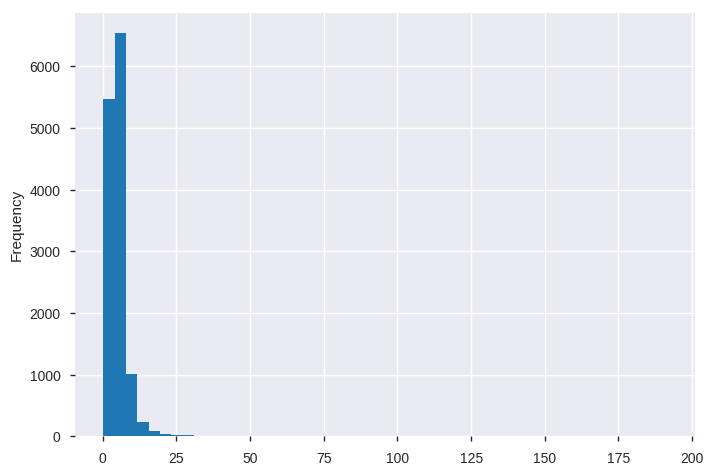

```python
# Delivery Time Histogram
df.DeliveryTime.plot.hist(bins=50)
```

### Feature Engineering

In this section we are going to explore the data and create the features for the model.

Previous analysis shows that:

- Some features can be discarded because they have the same meaning, e.g.: (Lat+Long) or (Country+City).
- ID information doesn't seem relevant for the current problem (OrderID, PartnerID, etc).
- IsHazMat is a constant in this dataset. If we keep it, the model won't know what to do with a different information, so it can be discarded in this project (altough it raises a concern on having different cases for this feature in a new dataset).
- Categories can (and will) be encoded, keeping the most frequent ones, while the least frequent categories are going to be blended in a category called "others".
- Sub-categories have a high cardinallity, so they are not suitable for efficient one-hot encoding and will be dropped
- Some important information are missing (e.g.: Lat, Long). We will try to replace it whenever we can, otherwise it is going to be discarded.
- We will create a new feature by calculating the distance between partner and customer using their lat/long info, because it seems like a very important feature.

```python
# Creates a new dataset where data is going to be transformed (mf=model features)
mf = df.copy()
```

#### Dropping unused

```python
# Dropping features we are not going to use
def dropUnused(modelFeatures):
    modelFeatures.drop(labels='IsHazmat', axis=1, inplace=True)
    modelFeatures.drop(labels='OrderLineID', axis=1, inplace=True)
    modelFeatures.drop(labels='OrderCodeID', axis=1, inplace=True)
    modelFeatures.drop(labels='PartnerID', axis=1, inplace=True)
    modelFeatures.drop(labels='TariffCode', axis=1, inplace=True)
    modelFeatures.drop(labels='CustomerCountry', axis=1, inplace=True)
    modelFeatures.drop(labels='CustomerCity', axis=1, inplace=True)
    modelFeatures.drop(labels='PartnerCountry', axis=1, inplace=True)
    modelFeatures.drop(labels='PartnerCity', axis=1, inplace=True)
    modelFeatures.drop(labels='DdpSubcategory', axis=1, inplace=True)
    modelFeatures.drop(labels='Category2ndLevel', axis=1, inplace=True)
    return modelFeatures
```

```python
# Applying changes to dataset
mf = dropUnused(mf)
```

```python
# Verifying function
mf.head()
```

|  | CustomerLatitude | CustomerLongitude | PartnerLatitude | PartnerLongitude | DeliveryType | DdpCategory | Category1stLevel | OrderDate | DeliveryTime |
| --- | --- | --- | --- | --- | --- | --- | --- | --- | --- |
| 0 | 1.280094 | 103.850949 | 51.331300 | 0.445068 | Express | Clothing & Accessories | Clothing | 2017-05-11 08:39:40 | 4.04 |
| 1 | 39.904030 | 116.407526 | 45.962640 | 12.655136 | Express | Bags & similar | Bags | 2016-02-04 13:19:13 | 9.88 |
| 2 | 53.390180 | -2.350904 | 41.872389 | 12.480180 | Standard | Clothing & Accessories | Clothing | 2016-07-12 12:08:41 | 6.88 |
| 3 | 43.204665 | 27.910542 | 45.676552 | 9.236743 | Express | default value | Bags | 2017-07-26 13:30:31 | 5.83 |
| 4 | 57.048819 | 9.921747 | 44.057082 | 12.564600 | Standard | Clothing & Accessories | Clothing | 2017-03-09 09:53:18 | 6.25 |

#### Trying to figure out coordenates from City/Coutry

Altough technically possible on a few examples, the webservice doesn't allow us to iterate through so many rows, so it was not possible to do this transformation.

```python
# Filling in missing Lat/Long - Webservice did not support multiple calls
def defLatLong(modelFeatures):
    geolocator = Nominatim(user_agent="defLatLong")

    for index, row in modelFeatures.iterrows():
        time.sleep(5)
        if pd.isnull(row['CustomerLongitude']):
            location = geolocator.geocode("{},{}".format(row['CustomerCity'],row['CustomerCountry']))
            if pd.notnull(location):
                row['CustomerLongitude'] = location.longitude
                row['CustomerLatitude'] = location.latitude

        if pd.isnull(row['PartnerLongitude']):
            location = geolocator.geocode("{},{}".format(row['PartnerCity'],row['PartnerCountry']))
            if pd.notnull(location):
                row['PartnerLongitude'] = location.longitude
                row['PartnerLatitude'] = location.latitude

    return modelFeatures
```

#### Dropping Nulls

```python
# Drop Nulls
def dropNulls(modelFeatures):
    modelFeatures.dropna(subset=['CustomerLongitude','CustomerLatitude','PartnerLongitude','PartnerLatitude'], how='any', axis=0, inplace=True)
    return modelFeatures
```

```python
# Verifying function
mf.shape
```

```
(13441, 9)
```

```python
# Dropping nulls
mf = dropNulls(mf)
```

```python
# Verifying function
mf.shape
```

```
(11435, 9)
```

```python
# Verifying function
mf.PartnerLongitude.isnull().sum()
```

```
0
```

#### Calculating distance between partner and customer

```python
# Calculates distance between coordinates
def calcDist(modelFeatures):
    modelFeatures['DistanceKM'] = modelFeatures.apply(lambda x: distance.distance( (x['CustomerLatitude'],x['CustomerLongitude']) , (x['PartnerLatitude'],x['PartnerLongitude']) ).km, axis=1)
    return modelFeatures
```

```python
mf = calcDist(mf)
```

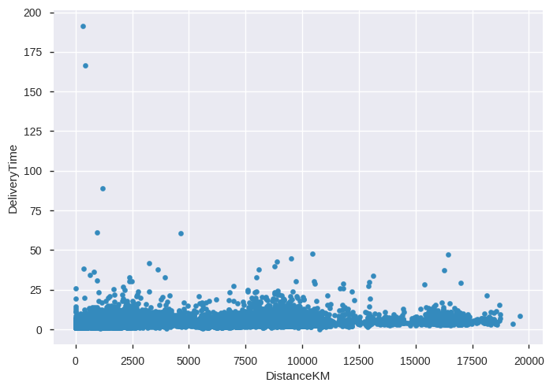

```python
# Verifying function
mf.plot.scatter(x='DistanceKM',y='DeliveryTime')
```

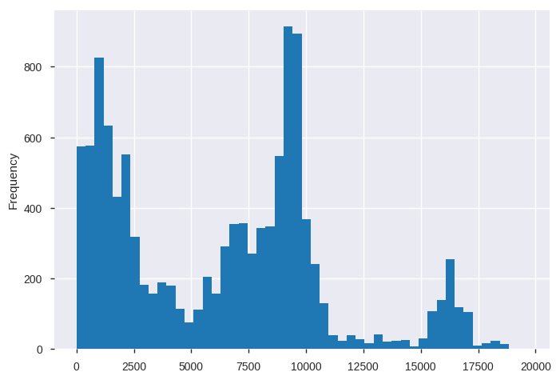

```python
# Distance Histogram
mf.DistanceKM.plot.hist(bins=50)
```

#### Preparing categorical variables

```python
# Preparing categorical variables for one hot encoding
def prepareEncoding(modelFeatures):
    modelFeatures['DeliveryType'] = modelFeatures.DeliveryType.apply(str).apply(lambda x: 1 if x == 'Express' else 0)
    modelFeatures['DdpCategory'] = modelFeatures.DdpCategory.apply(str).apply(lambda x: 'CategoryClothing' if x == 'Clothing & Accessories' else ('CategoryFootwear' if x[:8] == 'Footwear' else 'CategoryOthers'))
    modelFeatures['Category1stLevel'] = modelFeatures.Category1stLevel.apply(str).apply(lambda x: 'LevelClothing' if x == 'Clothing' else ('LevelShoes' if x == 'Shoes'  else ('LevelBags' if x == 'Bags'  else 'LevelOthers')))
    return modelFeatures
```

```python
# Applying changes
mf = prepareEncoding(mf)
```

```python
# Verifying changes
mf.head()
```

|  | CustomerLatitude | CustomerLongitude | PartnerLatitude | PartnerLongitude | DeliveryType | DdpCategory | Category1stLevel | OrderDate | DeliveryTime | DistanceKM |
| --- | --- | --- | --- | --- | --- | --- | --- | --- | --- | --- |
| 0 | 1.280094 | 103.850949 | 51.331300 | 0.445068 | 1 | CategoryClothing | LevelClothing | 2017-05-11 08:39:40 | 4.04 | 10825.760767 |
| 1 | 39.904030 | 116.407526 | 45.962640 | 12.655136 | 1 | CategoryOthers | LevelBags | 2016-02-04 13:19:13 | 9.88 | 7855.653960 |
| 2 | 53.390180 | -2.350904 | 41.872389 | 12.480180 | 0 | CategoryClothing | LevelClothing | 2016-07-12 12:08:41 | 6.88 | 1690.909103 |
| 3 | 43.204665 | 27.910542 | 45.676552 | 9.236743 | 1 | CategoryOthers | LevelBags | 2017-07-26 13:30:31 | 5.83 | 1508.159616 |
| 4 | 57.048819 | 9.921747 | 44.057082 | 12.564600 | 0 | CategoryClothing | LevelClothing | 2017-03-09 09:53:18 | 6.25 | 1456.989327 |

#### Getting month from data

```python
# Get month from date due to seasonality
def getMonth(modelFeatures):
    modelFeatures['OrderDate'] = modelFeatures.OrderDate.str.slice(5,7)
    modelFeatures.rename(index=str, columns={'OrderDate':'OrderMonth'}, inplace=True)
    return modelFeatures
```

```python
# Applying changes
mf = getMonth(mf)
```

```python
# Verifying changes
mf.head()
```

|  | CustomerLatitude | CustomerLongitude | PartnerLatitude | PartnerLongitude | DeliveryType | DdpCategory | Category1stLevel | OrderMonth | DeliveryTime | DistanceKM |
| --- | --- | --- | --- | --- | --- | --- | --- | --- | --- | --- |
| 0 | 1.280094 | 103.850949 | 51.331300 | 0.445068 | 1 | CategoryClothing | LevelClothing | 05 | 4.04 | 10825.760767 |
| 1 | 39.904030 | 116.407526 | 45.962640 | 12.655136 | 1 | CategoryOthers | LevelBags | 02 | 9.88 | 7855.653960 |
| 2 | 53.390180 | -2.350904 | 41.872389 | 12.480180 | 0 | CategoryClothing | LevelClothing | 07 | 6.88 | 1690.909103 |
| 3 | 43.204665 | 27.910542 | 45.676552 | 9.236743 | 1 | CategoryOthers | LevelBags | 07 | 5.83 | 1508.159616 |
| 4 | 57.048819 | 9.921747 | 44.057082 | 12.564600 | 0 | CategoryClothing | LevelClothing | 03 | 6.25 | 1456.989327 |

#### Encoding categorical variables

```python
def encodeCategories(modelFeatures):
    modelFeatures['CategoryClothing'] = modelFeatures.DdpCategory.apply(str).apply(lambda x: 1 if x == 'CategoryClothing' else 0)
    modelFeatures['CategoryFootwear'] = modelFeatures.DdpCategory.apply(str).apply(lambda x: 1 if x == 'CategoryFootwear' else 0)
    modelFeatures['CategoryOthers'] = modelFeatures.DdpCategory.apply(str).apply(lambda x: 1 if x == 'CategoryOthers' else 0)

    modelFeatures['Category1stLevel'] = modelFeatures.Category1stLevel.apply(str).apply(lambda x: 'LevelClothing' if x == 'Clothing' else ('LevelShoes' if x == 'Shoes'  else ('LevelBags' if x == 'Bags'  else 'LevelOthers')))
    modelFeatures['LevelClothing'] = modelFeatures.Category1stLevel.apply(str).apply(lambda x: 1 if x == 'LevelClothing' else 0)
    modelFeatures['LevelShoes'] = modelFeatures.Category1stLevel.apply(str).apply(lambda x: 1 if x == 'LevelShoes' else 0)
    modelFeatures['LevelBags'] = modelFeatures.Category1stLevel.apply(str).apply(lambda x: 1 if x == 'LevelBags' else 0)
    modelFeatures['LevelOthers'] = modelFeatures.Category1stLevel.apply(str).apply(lambda x: 1 if x == 'LevelOthers' else 0)

    return modelFeatures
```

```python
# Applying changes
mf = encodeCategories(mf)
```

```python
# Verifying changes
mf.head()
```

|  | CustomerLatitude | CustomerLongitude | PartnerLatitude | PartnerLongitude | DeliveryType | DdpCategory | Category1stLevel | OrderMonth | DeliveryTime | DistanceKM | CategoryClothing | CategoryFootwear | CategoryOthers | LevelClothing | LevelShoes | LevelBags | LevelOthers |
| --- | --- | --- | --- | --- | --- | --- | --- | --- | --- | --- | --- | --- | --- | --- | --- | --- | --- |
| 0 | 1.280094 | 103.850949 | 51.331300 | 0.445068 | 1 | CategoryClothing | LevelOthers | 05 | 4.04 | 10825.760767 | 1 | 0 | 0 | 0 | 0 | 0 | 1 |
| 1 | 39.904030 | 116.407526 | 45.962640 | 12.655136 | 1 | CategoryOthers | LevelOthers | 02 | 9.88 | 7855.653960 | 0 | 0 | 1 | 0 | 0 | 0 | 1 |
| 2 | 53.390180 | -2.350904 | 41.872389 | 12.480180 | 0 | CategoryClothing | LevelOthers | 07 | 6.88 | 1690.909103 | 1 | 0 | 0 | 0 | 0 | 0 | 1 |
| 3 | 43.204665 | 27.910542 | 45.676552 | 9.236743 | 1 | CategoryOthers | LevelOthers | 07 | 5.83 | 1508.159616 | 0 | 0 | 1 | 0 | 0 | 0 | 1 |
| 4 | 57.048819 | 9.921747 | 44.057082 | 12.564600 | 0 | CategoryClothing | LevelOthers | 03 | 6.25 | 1456.989327 | 1 | 0 | 0 | 0 | 0 | 0 | 1 |

#### Dropping already used features

```python
# Dropping features we are not going to use
def dropUsed(modelFeatures):
    modelFeatures.drop(labels='DdpCategory', axis=1, inplace=True)
    modelFeatures.drop(labels='Category1stLevel', axis=1, inplace=True)

    return modelFeatures
```

```python
# Applying changes
mf = dropUsed(mf)
```

```python
# Verifying changes
mf.head()
```

|  | CustomerLatitude | CustomerLongitude | PartnerLatitude | PartnerLongitude | DeliveryType | OrderMonth | DeliveryTime | DistanceKM | CategoryClothing | CategoryFootwear | CategoryOthers | LevelClothing | LevelShoes | LevelBags | LevelOthers |
| --- | --- | --- | --- | --- | --- | --- | --- | --- | --- | --- | --- | --- | --- | --- | --- |
| 0 | 1.280094 | 103.850949 | 51.331300 | 0.445068 | 1 | 05 | 4.04 | 10825.760767 | 1 | 0 | 0 | 0 | 0 | 0 | 1 |
| 1 | 39.904030 | 116.407526 | 45.962640 | 12.655136 | 1 | 02 | 9.88 | 7855.653960 | 0 | 0 | 1 | 0 | 0 | 0 | 1 |
| 2 | 53.390180 | -2.350904 | 41.872389 | 12.480180 | 0 | 07 | 6.88 | 1690.909103 | 1 | 0 | 0 | 0 | 0 | 0 | 1 |
| 3 | 43.204665 | 27.910542 | 45.676552 | 9.236743 | 1 | 07 | 5.83 | 1508.159616 | 0 | 0 | 1 | 0 | 0 | 0 | 1 |
| 4 | 57.048819 | 9.921747 | 44.057082 | 12.564600 | 0 | 03 | 6.25 | 1456.989327 | 1 | 0 | 0 | 0 | 0 | 0 | 1 |

### Model Selection

In this section we are going to use the features that we have prepared, in order to choose the best model.

We will train the following models:

- Linear Regression
- Decision Tree
- Random Forest
- AdaBoost

```python
# Creating the dataframe
modelDf = df.copy()
```

```python
# Applying feature engineering transformations
modelDf = dropUnused(modelDf)
modelDf = dropNulls(modelDf)
modelDf = calcDist(modelDf)
modelDf = prepareEncoding(modelDf)
modelDf = getMonth(modelDf)
modelDf = encodeCategories(modelDf)
modelDf = dropUsed(modelDf)
```

```python
# Verifying changes
modelDf.head()
```

|  | CustomerLatitude | CustomerLongitude | PartnerLatitude | PartnerLongitude | DeliveryType | OrderMonth | DeliveryTime | DistanceKM | CategoryClothing | CategoryFootwear | CategoryOthers | LevelClothing | LevelShoes | LevelBags | LevelOthers |
| --- | --- | --- | --- | --- | --- | --- | --- | --- | --- | --- | --- | --- | --- | --- | --- |
| 0 | 1.280094 | 103.850949 | 51.331300 | 0.445068 | 1 | 05 | 4.04 | 10825.760767 | 1 | 0 | 0 | 0 | 0 | 0 | 1 |
| 1 | 39.904030 | 116.407526 | 45.962640 | 12.655136 | 1 | 02 | 9.88 | 7855.653960 | 0 | 0 | 1 | 0 | 0 | 0 | 1 |
| 2 | 53.390180 | -2.350904 | 41.872389 | 12.480180 | 0 | 07 | 6.88 | 1690.909103 | 1 | 0 | 0 | 0 | 0 | 0 | 1 |
| 3 | 43.204665 | 27.910542 | 45.676552 | 9.236743 | 1 | 07 | 5.83 | 1508.159616 | 0 | 0 | 1 | 0 | 0 | 0 | 1 |
| 4 | 57.048819 | 9.921747 | 44.057082 | 12.564600 | 0 | 03 | 6.25 | 1456.989327 | 1 | 0 | 0 | 0 | 0 | 0 | 1 |

```python
# Splitting X and Y
X = modelDf.drop(['DeliveryTime'], axis=1)
y = modelDf['DeliveryTime']

#Scaling X
col_names = ['CustomerLatitude', 'CustomerLongitude','PartnerLatitude','PartnerLongitude','DistanceKM']
scaler = StandardScaler().fit(X[col_names])
X[col_names] = scaler.transform(X[col_names])
X.head()
```

|  | CustomerLatitude | CustomerLongitude | PartnerLatitude | PartnerLongitude | DeliveryType | OrderMonth | DistanceKM | CategoryClothing | CategoryFootwear | CategoryOthers | LevelClothing | LevelShoes | LevelBags | LevelOthers |
| --- | --- | --- | --- | --- | --- | --- | --- | --- | --- | --- | --- | --- | --- | --- |
| 0 | -1.331896 | 0.995171 | 0.819628 | -0.179016 | 1 | 05 | 0.988887 | 1 | 0 | 0 | 0 | 0 | 0 | 1 |
| 1 | 0.288562 | 1.141824 | 0.229494 | 0.204159 | 1 | 02 | 0.340174 | 0 | 0 | 1 | 0 | 0 | 0 | 1 |
| 2 | 0.854371 | -0.245203 | -0.220114 | 0.198668 | 0 | 07 | -1.006292 | 1 | 0 | 0 | 0 | 0 | 0 | 1 |
| 3 | 0.427040 | 0.108233 | 0.198047 | 0.096883 | 1 | 07 | -1.046208 | 0 | 0 | 1 | 0 | 0 | 0 | 1 |
| 4 | 1.007868 | -0.101866 | 0.020032 | 0.201317 | 0 | 03 | -1.057384 | 1 | 0 | 0 | 0 | 0 | 0 | 1 |

```python
# Splitting train and validation
X_train, X_test, y_train, y_test = train_test_split(X, y, test_size=0.25, random_state=42)
```

```python
#Definig hyperparameters space
params ={
    'LinearRegression':{'fit_intercept':[True,False]},
    'DecisionTree':{'criterion':['mse','friedman_mse','mae'],
                    'splitter':['best','random']},
    'RandomForest':{'n_estimators':[10,50,100],
                    'criterion':['mse','mae']},
    'AdaBoost':{'base_estimator':[DecisionTreeRegressor(max_depth=3),
                    DecisionTreeRegressor(max_depth=5),
                    DecisionTreeRegressor(max_depth=10)],
                'n_estimators':[50,75,100],
                'learning_rate':[0.1,1,10],
                'loss':['linear','square','exponential']}
}
```

```python
#Defining models
models = {
    'LinearRegression':LinearRegression(),
    'DecisionTree':DecisionTreeRegressor(),
    'RandomForest':RandomForestRegressor(),
    'AdaBoost':AdaBoostRegressor()
}
```

```python
#Defining GridSearch selection helper
class EstimatorSelectionHelper:

    def __init__(self, models, params):
        if not set(models.keys()).issubset(set(params.keys())):
            missing_params = list(set(models.keys()) - set(params.keys()))
            raise ValueError("Some estimators are missing parameters: %s" % missing_params)
        self.models = models
        self.params = params
        self.keys = models.keys()
        self.grid_searches = {}

    def fit(self, X, y, cv=3, n_jobs=3, verbose=1, scoring=None, refit=False):
        for key in self.keys:
            print("Running GridSearchCV for %s." % key)
            model = self.models[key]
            params = self.params[key]
            gs = GridSearchCV(model, params, cv=cv, n_jobs=n_jobs,
                              verbose=verbose, scoring=scoring, refit=refit,
                              return_train_score=True)
            gs.fit(X,y)
            self.grid_searches[key] = gs

    def score_summary(self, sort_by='mean_score'):
        def row(key, scores, params):
            d = {
                 'estimator': key,
                 'min_score': min(scores),
                 'max_score': max(scores),
                 'mean_score': np.mean(scores),
                 'std_score': np.std(scores),
            }
            return pd.Series({**params,**d})

        rows = []
        for k in self.grid_searches:
            print(k)
            params = self.grid_searches[k].cv_results_['params']
            scores = []
            for i in range(self.grid_searches[k].cv):
                key = "split{}_test_score".format(i)
                r = self.grid_searches[k].cv_results_[key]
                scores.append(r.reshape(len(params),1))

            all_scores = np.hstack(scores)
            for p, s in zip(params,all_scores):
                rows.append((row(k, s, p)))

        df = pd.concat(rows, axis=1).T.sort_values([sort_by], ascending=False)

        columns = ['estimator', 'min_score', 'mean_score', 'max_score', 'std_score']
        columns = columns + [c for c in df.columns if c not in columns]

        return df[columns]
```

```python
#Executing GridSearch
helper = EstimatorSelectionHelper(models, params)
helper.fit(X_train, y_train, scoring='neg_mean_squared_error', n_jobs=3)
```

```
Running GridSearchCV for LinearRegression.
Fitting 3 folds for each of 2 candidates, totalling 6 fits
```

```
[Parallel(n_jobs=3)]: Using backend LokyBackend with 3 concurrent workers.
[Parallel(n_jobs=3)]: Done   6 out of   6 | elapsed:    2.0s finished
[Parallel(n_jobs=3)]: Using backend LokyBackend with 3 concurrent workers.
```

```
Running GridSearchCV for DecisionTree.
Fitting 3 folds for each of 6 candidates, totalling 18 fits
```

```
[Parallel(n_jobs=3)]: Done  18 out of  18 | elapsed:    3.5s finished
[Parallel(n_jobs=3)]: Using backend LokyBackend with 3 concurrent workers.
```

```
Running GridSearchCV for RandomForest.
Fitting 3 folds for each of 6 candidates, totalling 18 fits
```

```
[Parallel(n_jobs=3)]: Done  18 out of  18 | elapsed:  1.9min finished
[Parallel(n_jobs=3)]: Using backend LokyBackend with 3 concurrent workers.
```

```
Running GridSearchCV for AdaBoost.
Fitting 3 folds for each of 81 candidates, totalling 243 fits
```

```
[Parallel(n_jobs=3)]: Done  44 tasks      | elapsed:    7.4s
[Parallel(n_jobs=3)]: Done 194 tasks      | elapsed:   42.2s
[Parallel(n_jobs=3)]: Done 243 out of 243 | elapsed:   50.4s finished
```

```python
#Verifying results
helper.score_summary(sort_by='max_score')
```

```
LinearRegression
DecisionTree
RandomForest
AdaBoost
```

|  | estimator | min_score | mean_score | max_score | std_score | base_estimator | criterion | fit_intercept | learning_rate | loss | n_estimators | splitter |
| --- | --- | --- | --- | --- | --- | --- | --- | --- | --- | --- | --- | --- |
| 75 | AdaBoost | -24.7256 | -14.0179 | -7.66099 | 7.61569 | DecisionTreeRegressor(criterion='mse', max_dep... | NaN | NaN | 0.1 | exponential | 75 | NaN |
| 76 | AdaBoost | -24.6462 | -14.0499 | -7.75424 | 7.5368 | DecisionTreeRegressor(criterion='mse', max_dep... | NaN | NaN | 0.1 | exponential | 100 | NaN |
| 71 | AdaBoost | -25.3752 | -14.2295 | -7.78196 | 7.91352 | DecisionTreeRegressor(criterion='mse', max_dep... | NaN | NaN | 0.1 | square | 50 | NaN |
| 47 | AdaBoost | -24.401 | -13.8863 | -7.81011 | 7.46498 | DecisionTreeRegressor(criterion='mse', max_dep... | NaN | NaN | 0.1 | exponential | 50 | NaN |
| 74 | AdaBoost | -24.69 | -14.0456 | -7.82959 | 7.56204 | DecisionTreeRegressor(criterion='mse', max_dep... | NaN | NaN | 0.1 | exponential | 50 | NaN |
| 69 | AdaBoost | -25.2585 | -14.227 | -7.87768 | 7.83009 | DecisionTreeRegressor(criterion='mse', max_dep... | NaN | NaN | 0.1 | linear | 75 | NaN |
| 44 | AdaBoost | -24.7016 | -18.2515 | -7.99319 | 7.3335 | DecisionTreeRegressor(criterion='mse', max_dep... | NaN | NaN | 0.1 | square | 50 | NaN |
| 41 | AdaBoost | -24.6159 | -14.1273 | -8.0714 | 7.4461 | DecisionTreeRegressor(criterion='mse', max_dep... | NaN | NaN | 0.1 | linear | 50 | NaN |
| 83 | AdaBoost | -24.9436 | -14.4232 | -8.07664 | 7.49175 | DecisionTreeRegressor(criterion='mse', max_dep... | NaN | NaN | 1 | exponential | 50 | NaN |
| 68 | AdaBoost | -24.7492 | -14.168 | -8.10003 | 7.50895 | DecisionTreeRegressor(criterion='mse', max_dep... | NaN | NaN | 0.1 | linear | 50 | NaN |
| 72 | AdaBoost | -25.3676 | -14.4921 | -8.15075 | 7.72549 | DecisionTreeRegressor(criterion='mse', max_dep... | NaN | NaN | 0.1 | square | 75 | NaN |
| 73 | AdaBoost | -25.4412 | -14.5641 | -8.23623 | 7.72543 | DecisionTreeRegressor(criterion='mse', max_dep... | NaN | NaN | 0.1 | square | 100 | NaN |
| 70 | AdaBoost | -25.2846 | -14.4154 | -8.26421 | 7.70794 | DecisionTreeRegressor(criterion='mse', max_dep... | NaN | NaN | 0.1 | linear | 100 | NaN |
| 78 | AdaBoost | -24.9671 | -14.6678 | -8.33825 | 7.34611 | DecisionTreeRegressor(criterion='mse', max_dep... | NaN | NaN | 1 | linear | 75 | NaN |
| 1 | LinearRegression | -24.6962 | -14.3244 | -8.41842 | 7.35748 | NaN | NaN | False | NaN | NaN | NaN | NaN |
| 0 | LinearRegression | -24.6962 | -14.3244 | -8.41842 | 7.35748 | NaN | NaN | True | NaN | NaN | NaN | NaN |
| 48 | AdaBoost | -24.6265 | -14.2814 | -8.43673 | 7.33566 | DecisionTreeRegressor(criterion='mse', max_dep... | NaN | NaN | 0.1 | exponential | 75 | NaN |
| 87 | AdaBoost | -290.323 | -103.127 | -8.44035 | 132.371 | DecisionTreeRegressor(criterion='mse', max_dep... | NaN | NaN | 10 | linear | 75 | NaN |
| 85 | AdaBoost | -25.4274 | -18.9969 | -8.50338 | 7.4827 | DecisionTreeRegressor(criterion='mse', max_dep... | NaN | NaN | 1 | exponential | 100 | NaN |
| 84 | AdaBoost | -25.2568 | -18.8625 | -8.52764 | 7.37617 | DecisionTreeRegressor(criterion='mse', max_dep... | NaN | NaN | 1 | exponential | 75 | NaN |
| 80 | AdaBoost | -25.0705 | -18.7386 | -8.70336 | 7.17666 | DecisionTreeRegressor(criterion='mse', max_dep... | NaN | NaN | 1 | square | 50 | NaN |
| 82 | AdaBoost | -25.0304 | -14.7868 | -8.80619 | 7.27717 | DecisionTreeRegressor(criterion='mse', max_dep... | NaN | NaN | 1 | square | 100 | NaN |
| 20 | AdaBoost | -24.7744 | -14.5139 | -8.83558 | 7.2691 | DecisionTreeRegressor(criterion='mse', max_dep... | NaN | NaN | 0.1 | exponential | 50 | NaN |
| 86 | AdaBoost | -465.061 | -161.859 | -8.8639 | 214.399 | DecisionTreeRegressor(criterion='mse', max_dep... | NaN | NaN | 10 | linear | 50 | NaN |
| 9 | RandomForest | -24.594 | -14.6422 | -8.93539 | 7.06221 | NaN | mse | NaN | NaN | NaN | 50 | NaN |
| 10 | RandomForest | -24.7085 | -14.7298 | -9.01243 | 7.08102 | NaN | mse | NaN | NaN | NaN | 100 | NaN |
| 49 | AdaBoost | -24.9904 | -14.7865 | -9.04809 | 7.23397 | DecisionTreeRegressor(criterion='mse', max_dep... | NaN | NaN | 0.1 | exponential | 100 | NaN |
| 13 | RandomForest | -24.4293 | -14.8497 | -9.06583 | 6.82228 | NaN | mae | NaN | NaN | NaN | 100 | NaN |
| 12 | RandomForest | -24.3172 | -14.9001 | -9.08234 | 6.72019 | NaN | mae | NaN | NaN | NaN | 50 | NaN |
| 59 | AdaBoost | -25.9759 | -15.4079 | -9.33378 | 7.50052 | DecisionTreeRegressor(criterion='mse', max_dep... | NaN | NaN | 10 | linear | 50 | NaN |
| ... | ... | ... | ... | ... | ... | ... | ... | ... | ... | ... | ... | ... |
| 91 | AdaBoost | -1437.68 | -496.418 | -24.4345 | 665.573 | DecisionTreeRegressor(criterion='mse', max_dep... | NaN | NaN | 10 | square | 100 | NaN |
| 55 | AdaBoost | -46.6181 | -32.2187 | -24.6417 | 10.1866 | DecisionTreeRegressor(criterion='mse', max_dep... | NaN | NaN | 1 | square | 100 | NaN |
| 35 | AdaBoost | -1777.83 | -612.056 | -25.0411 | 824.332 | DecisionTreeRegressor(criterion='mse', max_dep... | NaN | NaN | 10 | square | 50 | NaN |
| 57 | AdaBoost | -46.8882 | -35.6015 | -26.064 | 8.59093 | DecisionTreeRegressor(criterion='mse', max_dep... | NaN | NaN | 1 | exponential | 75 | NaN |
| 89 | AdaBoost | -44.7486 | -34.0155 | -27.1187 | 7.69159 | DecisionTreeRegressor(criterion='mse', max_dep... | NaN | NaN | 10 | square | 50 | NaN |
| 40 | AdaBoost | -717.925 | -332.144 | -27.8535 | 287.553 | DecisionTreeRegressor(criterion='mse', max_dep... | NaN | NaN | 10 | exponential | 100 | NaN |
| 62 | AdaBoost | -113.15 | -58.2631 | -28.3408 | 38.8634 | DecisionTreeRegressor(criterion='mse', max_dep... | NaN | NaN | 10 | square | 50 | NaN |
| 63 | AdaBoost | -872.526 | -311.395 | -28.3597 | 396.785 | DecisionTreeRegressor(criterion='mse', max_dep... | NaN | NaN | 10 | square | 75 | NaN |
| 25 | AdaBoost | -72.101 | -45.5397 | -28.5012 | 19.0306 | DecisionTreeRegressor(criterion='mse', max_dep... | NaN | NaN | 1 | linear | 100 | NaN |
| 64 | AdaBoost | -964.851 | -342.272 | -28.6652 | 440.234 | DecisionTreeRegressor(criterion='mse', max_dep... | NaN | NaN | 10 | square | 100 | NaN |
| 24 | AdaBoost | -60.8635 | -44.8754 | -29.2747 | 12.899 | DecisionTreeRegressor(criterion='mse', max_dep... | NaN | NaN | 1 | linear | 75 | NaN |
| 23 | AdaBoost | -35.9029 | -32.5865 | -29.3283 | 2.68438 | DecisionTreeRegressor(criterion='mse', max_dep... | NaN | NaN | 1 | linear | 50 | NaN |
| 58 | AdaBoost | -65.0839 | -45.5971 | -30.2345 | 14.523 | DecisionTreeRegressor(criterion='mse', max_dep... | NaN | NaN | 1 | exponential | 100 | NaN |
| 90 | AdaBoost | -85.4881 | -49.8014 | -30.6172 | 25.258 | DecisionTreeRegressor(criterion='mse', max_dep... | NaN | NaN | 10 | square | 75 | NaN |
| 36 | AdaBoost | -176.616 | -80.2067 | -30.7053 | 68.1799 | DecisionTreeRegressor(criterion='mse', max_dep... | NaN | NaN | 10 | square | 75 | NaN |
| 7 | DecisionTree | -57.4862 | -43.1331 | -31.2131 | 10.8631 | NaN | mae | NaN | NaN | NaN | NaN | random |
| 52 | AdaBoost | -59.9632 | -44.1148 | -33.5711 | 11.4088 | DecisionTreeRegressor(criterion='mse', max_dep... | NaN | NaN | 1 | linear | 100 | NaN |
| 26 | AdaBoost | -83.9591 | -54.9567 | -35.0054 | 20.985 | DecisionTreeRegressor(criterion='mse', max_dep... | NaN | NaN | 1 | square | 50 | NaN |
| 28 | AdaBoost | -160.925 | -78.2979 | -35.6139 | 58.4372 | DecisionTreeRegressor(criterion='mse', max_dep... | NaN | NaN | 1 | square | 100 | NaN |
| 51 | AdaBoost | -43.7864 | -38.7737 | -36.1107 | 3.54684 | DecisionTreeRegressor(criterion='mse', max_dep... | NaN | NaN | 1 | linear | 75 | NaN |
| 29 | AdaBoost | -112.76 | -83.1204 | -59.1754 | 22.2431 | DecisionTreeRegressor(criterion='mse', max_dep... | NaN | NaN | 1 | exponential | 50 | NaN |
| 30 | AdaBoost | -145.098 | -119.691 | -94.3856 | 20.7033 | DecisionTreeRegressor(criterion='mse', max_dep... | NaN | NaN | 1 | exponential | 75 | NaN |
| 92 | AdaBoost | -1050.93 | -482.348 | -116.464 | 407.53 | DecisionTreeRegressor(criterion='mse', max_dep... | NaN | NaN | 10 | exponential | 50 | NaN |
| 31 | AdaBoost | -145.698 | -136.289 | -126.527 | 7.83029 | DecisionTreeRegressor(criterion='mse', max_dep... | NaN | NaN | 1 | exponential | 100 | NaN |
| 65 | AdaBoost | -2635.47 | -1283.73 | -217.48 | 1007.57 | DecisionTreeRegressor(criterion='mse', max_dep... | NaN | NaN | 10 | exponential | 50 | NaN |
| 39 | AdaBoost | -5164.14 | -2882.05 | -220.526 | 2035.98 | DecisionTreeRegressor(criterion='mse', max_dep... | NaN | NaN | 10 | exponential | 75 | NaN |
| 38 | AdaBoost | -5321.07 | -2769.95 | -224.6 | 2080.63 | DecisionTreeRegressor(criterion='mse', max_dep... | NaN | NaN | 10 | exponential | 50 | NaN |
| 66 | AdaBoost | -3158.1 | -1288.79 | -238.165 | 1325.19 | DecisionTreeRegressor(criterion='mse', max_dep... | NaN | NaN | 10 | exponential | 75 | NaN |
| 94 | AdaBoost | -7055.55 | -4459.83 | -251.357 | 3002.78 | DecisionTreeRegressor(criterion='mse', max_dep... | NaN | NaN | 10 | exponential | 100 | NaN |
| 93 | AdaBoost | -7236.95 | -4350.63 | -295.949 | 2951.63 | DecisionTreeRegressor(criterion='mse', max_dep... | NaN | NaN | 10 | exponential | 75 | NaN |

95 rows × 12 columns

```python
res = helper.score_summary(sort_by='max_score')
```

```
LinearRegression
DecisionTree
RandomForest
AdaBoost
```

```python
res.iloc[0]['base_estimator']
```

```
DecisionTreeRegressor(criterion='mse', max_depth=10, max_features=None,
           max_leaf_nodes=None, min_impurity_decrease=0.0,
           min_impurity_split=None, min_samples_leaf=1,
           min_samples_split=2, min_weight_fraction_leaf=0.0,
           presort=False, random_state=None, splitter='best')
```

```python
res.iloc[0]
```

```
estimator                                                  AdaBoost
min_score                                                  -24.7256
mean_score                                                 -14.0179
max_score                                                  -7.66099
std_score                                                   7.61569
base_estimator    DecisionTreeRegressor(criterion='mse', max_dep...
criterion                                                       NaN
fit_intercept                                                   NaN
learning_rate                                                   0.1
loss                                                    exponential
n_estimators                                                     75
splitter                                                        NaN
Name: 75, dtype: object
```

```python
#Defining model
bestModel = AdaBoostRegressor(
    DecisionTreeRegressor(criterion='mse', max_depth=10, max_features=None,
           max_leaf_nodes=None, min_impurity_decrease=0.0,
           min_impurity_split=None, min_samples_leaf=1,
           min_samples_split=2, min_weight_fraction_leaf=0.0,
           presort=False, random_state=None, splitter='best'),
    learning_rate = 0.1,
    n_estimators = 75
)
```

```python
#Training model
bestModel.fit(X_train,y_train)
```

```
AdaBoostRegressor(base_estimator=DecisionTreeRegressor(criterion='mse', max_depth=10, max_features=None,
           max_leaf_nodes=None, min_impurity_decrease=0.0,
           min_impurity_split=None, min_samples_leaf=1,
           min_samples_split=2, min_weight_fraction_leaf=0.0,
           presort=False, random_state=None, splitter='best'),
         learning_rate=0.1, loss='linear', n_estimators=75,
         random_state=None)
```

```python
#Predicting
y_pred = bestModel.predict(X_test)
```

```python
#Verifying results
resultDf = X_test.copy()
resultDf['DeliveryTime'] = y_test
resultDf['PredictedTime'] = y_pred
```

```python
#Verifyng df
resultDf.head(30)
```

|  | CustomerLatitude | CustomerLongitude | PartnerLatitude | PartnerLongitude | DeliveryType | OrderMonth | DistanceKM | CategoryClothing | CategoryFootwear | CategoryOthers | LevelClothing | LevelShoes | LevelBags | LevelOthers | DeliveryTime | PredictedTime |
| --- | --- | --- | --- | --- | --- | --- | --- | --- | --- | --- | --- | --- | --- | --- | --- | --- |
| 7544 | -0.337199 | 1.199095 | -0.016709 | 0.133441 | 1 | 11 | 0.733126 | 0 | 0 | 1 | 0 | 0 | 0 | 1 | 5.75 | 4.457300 |
| 10790 | -2.972084 | 1.475338 | 0.813847 | -0.176611 | 1 | 03 | 2.307213 | 1 | 0 | 0 | 0 | 0 | 0 | 1 | 5.33 | 5.677643 |
| 9472 | 0.323138 | -1.082928 | -1.704932 | -2.788059 | 0 | 07 | -1.030247 | 0 | 0 | 1 | 0 | 0 | 0 | 1 | 3.25 | 5.628904 |
| 2694 | 0.953621 | 0.221602 | 0.008186 | -0.042177 | 1 | 10 | -0.793616 | 1 | 0 | 0 | 0 | 0 | 0 | 1 | 3.79 | 5.572488 |
| 6218 | -0.445965 | 1.114984 | -0.387291 | 0.377383 | 1 | 07 | 0.570410 | 0 | 0 | 1 | 0 | 0 | 0 | 1 | 5.62 | 4.501719 |
| 11223 | -0.324706 | 0.384132 | -0.220114 | 0.198668 | 1 | 11 | -0.497767 | 0 | 1 | 0 | 0 | 0 | 0 | 1 | 2.79 | 4.739892 |
| 12199 | -0.334733 | 0.426744 | -0.348366 | -2.514552 | 1 | 03 | 1.034791 | 0 | 1 | 0 | 0 | 0 | 0 | 1 | 4.92 | 5.116997 |
| 1616 | 0.775426 | -0.219211 | -0.643837 | 0.200458 | 0 | 03 | -0.982939 | 1 | 0 | 0 | 0 | 0 | 0 | 1 | 6.58 | 7.206549 |
| 7214 | -2.538142 | 1.569476 | 0.918379 | 0.466420 | 1 | 04 | 1.944410 | 1 | 0 | 0 | 0 | 0 | 0 | 1 | 5.08 | 5.290000 |
| 1606 | -0.449232 | 1.115803 | -0.220114 | 0.198668 | 1 | 02 | 0.655026 | 1 | 0 | 0 | 0 | 0 | 0 | 1 | 5.29 | 4.100956 |
| 2064 | -1.331896 | 0.995171 | 0.918379 | 0.466420 | 1 | 01 | 0.679166 | 1 | 0 | 0 | 0 | 0 | 0 | 1 | 4.04 | 4.685000 |
| 7386 | -0.075337 | 1.200994 | -0.332302 | 0.254777 | 1 | 10 | 0.607995 | 1 | 0 | 0 | 0 | 0 | 0 | 1 | 3.96 | 5.661286 |
| 6468 | -0.348830 | 0.327964 | 0.171867 | 0.151954 | 1 | 12 | -0.515656 | 1 | 0 | 0 | 0 | 0 | 0 | 1 | 4.54 | 4.710830 |
| 2499 | -0.454374 | 1.108404 | 0.212503 | 0.092127 | 1 | 09 | 0.660748 | 0 | 1 | 0 | 0 | 0 | 0 | 1 | 14.17 | 4.820405 |
| 1019 | 0.775426 | -0.219211 | 0.915703 | -0.189161 | 1 | 12 | -1.358273 | 0 | 0 | 1 | 0 | 0 | 0 | 1 | 4.67 | 3.106107 |
| 4519 | 0.859339 | 0.359448 | 0.915703 | -0.189161 | 1 | 02 | -0.664239 | 1 | 0 | 0 | 0 | 0 | 0 | 1 | 24.04 | 5.932491 |
| 4441 | -0.075337 | 1.200994 | -7.411523 | -1.656424 | 1 | 09 | 2.680505 | 1 | 0 | 0 | 0 | 0 | 0 | 1 | 11.67 | 8.520000 |
| 9851 | 0.334757 | -1.079505 | 0.998084 | -0.229327 | 1 | 01 | -0.188629 | 1 | 0 | 0 | 0 | 0 | 0 | 1 | 3.46 | 3.200000 |
| 6374 | -0.445965 | 1.114984 | -0.503066 | 0.317089 | 1 | 02 | 0.613231 | 0 | 0 | 1 | 0 | 0 | 0 | 1 | 3.08 | 4.751492 |
| 5273 | 0.110424 | 1.414468 | 0.101858 | 0.131126 | 1 | 05 | 0.753039 | 1 | 0 | 0 | 0 | 0 | 0 | 1 | 5.88 | 4.823333 |
| 1776 | -0.332912 | 1.202000 | -0.365121 | 0.253335 | 1 | 01 | 0.715717 | 0 | 0 | 1 | 0 | 0 | 0 | 1 | 5.71 | 4.557229 |
| 3912 | -0.332912 | 1.202000 | -0.699869 | 0.280351 | 1 | 10 | 0.738312 | 1 | 0 | 0 | 0 | 0 | 0 | 1 | 5.46 | 6.139706 |
| 5205 | 0.288562 | 1.141824 | -0.220114 | 0.198668 | 1 | 11 | 0.404197 | 0 | 0 | 1 | 0 | 0 | 0 | 1 | 16.71 | 8.354737 |
| 3576 | -2.972084 | 1.475338 | -0.091290 | 0.177755 | 1 | 11 | 2.131237 | 0 | 0 | 1 | 0 | 0 | 0 | 1 | 5.25 | 5.677643 |
| 9708 | -2.806504 | 1.548260 | 0.918379 | 0.466420 | 1 | 03 | 2.028794 | 0 | 0 | 1 | 0 | 0 | 0 | 1 | 5.00 | 6.050196 |
| 11761 | 0.325582 | -1.080140 | 0.685481 | 0.079478 | 1 | 09 | -0.020703 | 0 | 1 | 0 | 0 | 0 | 0 | 1 | 2.75 | 3.673926 |
| 6131 | 0.976305 | 0.295401 | 0.199426 | 0.203653 | 1 | 06 | -0.837444 | 0 | 1 | 0 | 0 | 0 | 0 | 1 | 3.08 | 6.153929 |
| 4999 | -0.153305 | 0.342660 | -0.643837 | 0.200458 | 1 | 06 | -0.632921 | 1 | 0 | 0 | 0 | 0 | 0 | 1 | 5.00 | 5.871220 |
| 9171 | 0.969931 | 0.254311 | -0.303132 | 0.336488 | 1 | 11 | -0.854316 | 0 | 1 | 0 | 0 | 0 | 0 | 1 | 3.92 | 6.880000 |
| 1970 | 0.109942 | 1.413320 | 1.297216 | 0.201435 | 1 | 04 | 0.527663 | 0 | 1 | 0 | 0 | 0 | 0 | 1 | 4.08 | 4.957143 |